# MA0501 – Tarea 3

Autores/as

Diego Alberto Vega Víquez - C38367

José Carlos Quintero Cedeño - C26152

Gabriel Valverde Guzmán - C38060

Fecha de publicación

7 de septiembre de 2025

# Ejercicio 1

**Instrucción**

Desarrolle funciones iterativas y recursivas en R para los algoritmos de los métodos de:

- iteración de punto fijo,
- bisección,
- método de Newton–Raphson,
- método de la secante, y
- método de Steffensen vistos en clase,

y el método Regula–Falsi que se describe en el ejercicio 11.

## Solución

**Metodo de punto fijo**

**Código**

```r
punto.fijo <- function(p0, tol, n, g) {
  i <- 1
  p0_temp <- p0
  while (i <= n) {
    p <- g(p0_temp)
    if (abs(p - p0_temp) < tol) {
      return(list("valor" = p, "iteraciones" = i))
    }
    i <- i + 1
    p0_temp <- p
  }
  return(NULL)
}

punto.fijo.rec <- function(p0, tol, n, g) {
  p1 <- g(p0)
  if (abs(p1 - p0) < tol || n < 1) {
    if (n >= 1) {
      return(p1)
    }
    else{
      return(Inf)
    }
  }
  else{
    return(punto.fijo.rec(p1, tol, n - 1, g))
  }
}

f1 <- function(x) sqrt(1 + 1/x)

punto.fijo(1, 1e-8, 20, f1)
```

```
$valor
[1] 1.324718

$iteraciones
[1] 13
```

**Código**

```r
punto.fijo.rec(1, 1e-8, 20, f1)
```

```
[1] 1.324718
```

**Método de bisección**

**Código**

```r
biseccion <- function(a, b, tol, n, g) {
  i <- 1
  a1 <- a
  b1 <- b
  if (g(a) * g(b) > 0) {
    return("No se cumplen las hipotesis")
  }
  else{
    while (i <= n) {
      x <- (a1 + b1) / 2
      if (g(a1) * g(x) > 0) {
        a1 <- x
      }
      else{
        b1 <- x
      }
      if (abs(b1 - a1) < tol) {
        return(list("valor" = x, "iteraciones" = i))
      }
      i <- i + 1
    }
    return(NULL)
  }
}

biseccion.rec <- function(a, b, tol, n, g) {
  a1 <- a
  b1 <- b
  x <- (a + b) / 2
  if (abs(b1 - a1) < tol || n < 1) {
    if (n >= 1) {
      return(x)
    }
    else{
      return(x)
    }
  }
  else {
    if (g(a) * g(x) > 0) {
      return(biseccion.rec(x, b1, tol, n - 1, g))
    }
    else {
      return(biseccion.rec(a1, x, tol, n - 1, g))
    }
  }
}

f <- function(x) (cos(x))^2 - 2 * sin(x)

biseccion(0, 1, 1e-8, 100, f)
```

```
$valor
[1] 0.4270786

$iteraciones
[1] 27
```

**Código**

```r
biseccion.rec(0, 1, 1e-8, 100, f)
```

```
[1] 0.4270786
```

**Método de Newton-Raphson**

**Código**

```r
newton.raphson <- function(x0, tol, n, f, df) {
  i <- 1
  x0_temp <- x0
  while (i <= n) {
    x <- x0_temp - f(x0_temp) / df(x0_temp)
    if (abs(x - x0_temp) < tol) {
      return(list("valor" = x, "iteraciones" = i))
    }
    i <- i + 1
    x0_temp <- x
  }
  return(NULL)
}

newton.raphson.rec <- function(x0, tol, n, f, df) {
  x0_temp <- x0
  x <- x0_temp - f(x0_temp) / df(x0_temp)
  if (abs(x - x0) < tol || n < 1) {
    if (n >= 1) {
      return(x)
    }
    else{
      return(NULL)
    }
  }
  else{
    return(newton.raphson.rec(x, tol, n - 1, f, df))
  }
}

f <- function(x) (cos(x))^2 - 2 * sin(x)
df <- function(x) - 2 * cos(x) * sin(x) - 2 * sin(x)

newton.raphson(0.5, 1e-8, 100, f, df)
```

```
$valor
[1] 0.4270786

$iteraciones
[1] 36
```

**Código**

```r
newton.raphson.rec(0.5, 1e-8, 100, f, df)
```

```
[1] 0.4270786
```

**Método de la secante**

**Código**

```r
secante <- function(x0, x1, tol, n, f) {
  i <- 2
  x0.temp <- x0
  x1.temp <- x1
  while (i <= n) {
    x <- x1.temp - ((x0.temp - x1.temp) * f(x1.temp)) / (f(x0.temp) - f(x1.temp))
    if (abs(x - x0.temp) < tol) {
      return(list("valor" = x, "iteraciones" = i))
    }
    x0.temp <- x1.temp
    x1.temp <- x
    i <- i + 1
  }
  return(NULL)
}

secante.rec <- function(x0, x1, tol, n, f) {
  x <- x1 - ((x0 - x1) * f(x1)) / (f(x0) - f(x1))
  if (abs(x - x0) < tol || n < 1) {
    if (n >= 1) {
      return(x)
    }
    else{
      return(NULL)
    }
  }
  else{
    return(secante.rec(x1, x, tol, n - 1, f))
  }
}

g <- function(x) cos(x) - x^2

secante(0, 1, 1e-8, 100, g)
```

```
$valor
[1] 0.8241323

$iteraciones
[1] 8
```

**Código**

```r
secante.rec(0, 1, 1e-8, 100, g)
```

```
[1] 0.8241323
```

**Método de Steffensen**

**Código**

```r
steffensen <- function(x0, tol, n, f) {
  i <- 2
  x0.temp <- x0
  while (i <= n) {
    x1 <- f(x0.temp)
    x2 <- f(x1)
    x <- x0.temp - (x1 - x0.temp)^2 / (x2 - 2 * x1 + x0.temp)
    if (abs(x - x0.temp) < tol) {
      return(list("valor" = x, "iteraciones" = i))
    }
    i <- i + 1
    x0.temp <- x
  }
  return(NULL)
}

steffensen.rec <- function(x0, tol, n, f) {
  x1 <- f(x0)
  x2 <- f(x1)
  x <- x0 - (x1-x0)^2/(x2-2*x1+x0)
  if(abs(x - x0) < tol || n < 1){
    if(n>=1){
      return(x)
    }
    else{
      return(NULL)
    }
  }
  else{
    return(steffensen.rec(x, tol, n-1, f))
  }
}

f1 <- function(x) sqrt(1 + 1/x)

steffensen(1, 1e-8, 100, f1)
```

```
$valor
[1] 1.324718

$iteraciones
[1] 5
```

**Código**

```r
steffensen.rec(1, 1e-8, 100, f1)
```

```
[1] 1.324718
```

**Método Regula Falsi**

**Código**

```r
regula.falsi <- function(a,b, tol, n, f){
  i <- 1
  a.temp <- a
  b.temp <- b
  while (i <= n) {
    x <- (a.temp*f(b.temp) - b.temp*f(a.temp))/(f(b.temp) - f(a.temp))
    if(f(a.temp)*f(x) > 0){
      a.temp <- x
    }
    else{
      b.temp <- x
    }
    if(abs(b.temp-a.temp) < tol) {
      return(list("valor" = x, "iteraciones" = i))
    }
    i <- i + 1
  }
  return(NULL)
}

regula.falsi.rec <- function(a, b, tol, n, f) {
  a.temp <- a
  b.temp <- b
  x <- (a.temp*f(b.temp) - b.temp*f(a.temp))/(f(b.temp) - f(a.temp))
  if(abs(b.temp-a.temp)<tol || n<1){
    if(n>=1){
      return(x)
    }
    else{
      return(NULL)
    }
  }
  else{
    if(f(a)*f(x) > 0){
      return(regula.falsi.rec(x, b.temp, tol, n-1, f))
    }
    else{
      return(regula.falsi.rec(a.temp, x, tol, n-1, f))
    }
  }
}

f <- function(x) (cos(x))^2 - 2 * sin(x)

regula.falsi(0, 1, 1e-8, 100, f)
```

```
$valor
[1] 0.4270786

$iteraciones
[1] 6
```

**Código**

```r
regula.falsi.rec(0, 1, 1e-8, 100, f)
```

```
[1] 0.4270786
```

# Ejercicio 2

**Instrucción**

Use el procedimiento `Bisección` para resolver las siguientes ecuaciones, con por lo menos 5 dígitos significativos. Compare los resultados con los que se obtienen usando directamente `R`.

1. $\cos^2(x) = 2\sin(x)$ para $0 \leq x \leq 1$
2. $-x^3 + x + 1 = 0$ para $1 \leq x \leq 2$

Para cada una de las ecuaciones anteriores, de acuerdo con los teoremas de error vistos en clase, calcule el número de iteraciones necesarias para obtener la precisión pedida, y compare estos resultados con los obtenidos con **R**.

## Solución

**Código**

```r
f <- function(x) cos(x)^2 - 2*sin(x)
biseccion(0, 1, 1e-5, 30, f)
```

```
$valor
[1] 0.4270859

$iteraciones
[1] 17
```

**Código**

```r
#Calculo con R
raiz.a <- uniroot(f, c(0,1))$root
sprintf("%.20f", raiz.a)
```

```
[1] "0.42707795652908947526"
```

Para que se obtener la precision pedida, se requieren de teoreticamente mas de :

```r
round(5* log(10) / log(2))
```

```
[1] 17
```

iteraciones, lo cual es consistente con el resultado del codigo anterior

**Código**

```r
g <- function(x) -x^3 + x + 1
biseccion(1, 2, 1e-5, 30, g)
```

```
$valor
[1] 1.324715

$iteraciones
[1] 17
```

**Código**

```r
#Calculo con R
raiz.b <- uniroot(g, c(1,2))$root
sprintf("%.20f", raiz.b)
```

```
[1] "1.32471782512876834481"
```

Para obtener la precision pedida, se requieren, teoreticamente, de las mismas iteraciones que el inciso anterior (pues la longitud del intervalo es la misma), lo cual es consistente con lo obtenido ahora.

# Ejercicio 3

**Instrucción**

Use el procedimiento `Bisección` para resolver las siguientes ecuaciones, con por lo menos 4 dígitos significativos. Compare los resultados con los que se obtienen usando directamente `R`.

1. $e^x + 4x - 5 = 0$
2. $x^4 - 2x - 1 = 0$

Determine gráficamente un intervalo inicial $[a, b]$, con $a, b \in \mathbb{Z}$.

## Solución

Grafico de las funciones:

**Código**

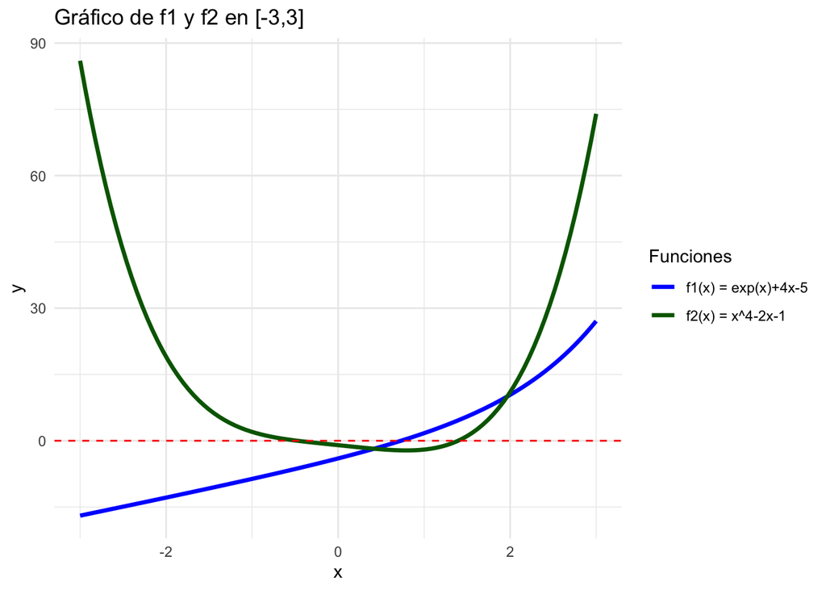

```r
library(ggplot2)

f1 <- function(x) exp(x) + 4*x - 5
f2 <- function(x) x^4 - 2*x - 1

ggplot(data.frame(x = c(-3, 3)), aes(x)) +
  stat_function(fun = f1, aes(colour = "f1(x) = exp(x)+4x-5"), size = 1.2) +
  stat_function(fun = f2, aes(colour = "f2(x) = x^4-2x-1"), size = 1.2) +
  geom_hline(yintercept = 0, colour = "red", linetype = "dashed") +
  scale_colour_manual(values = c("blue", "darkgreen")) +
  labs(y = "y", colour = "Funciones",
       title = "Gráfico de f1 y f2 en [-3,3]") +
  theme_minimal()
```

Con base en este grafico, es razonable determinar que f1 = 0 en el intervalo [0,1], y que f2 = 0 en el intervalo [1,2] y en [-1,0]

**Código**

```r
biseccion(0,1,1e-4,30,f1)
```

```
$valor
[1] 0.7307739

$iteraciones
[1] 14
```

**Código**

```r
#Calculo con R
raiz.a <- uniroot(f1,c(0,1))$root
sprintf("%.20f", raiz.a)
```

```
[1] "0.73080970231405351090"
```

**Código**

```r
#Raiz en intervalo [1,2]
biseccion(1,2,1e-4,30,f2)$valor
```

```
[1] 1.395325
```

**Código**

```r
#Calculo con R
raiz.b.1 <- uniroot(f2,c(1,2))$root
sprintf("%.20f", raiz.b.1)
```

```
[1] "1.39532879208128846038"
```

**Código**

```r
#Raiz en intervalo [-1,0]
biseccion(-1,0,1e-4,30,f2)$valor
```

```
[1] -0.4746704
```

**Código**

```r
#Calculo con R
raiz.b.2 <- uniroot(f2,c(-1,0))$root
sprintf("%.20f", raiz.b.2)
```

```
[1] "-0.47461369980099188393"
```

# Ejercicio 4

**Instrucción**

Para cada una de las siguientes ecuaciones, determine el intervalo $[a, b]$ en el cual la iteración de punto fijo converge. Estime el número de iteraciones necesarias para obtener aproximaciones con 5 dígitos significativos, y efectúe los cálculos con el procedimiento `PuntoFijo`. Compare los resultados con los que se obtienen usando directamente `R`.

1. $e^{-x} - x = 0$
2. $e^x = 3x$

## Solución

```r
f1 <- function(x) exp(-x) - x
f1.f <- function(x) exp(-x)
f2 <- function(x) exp(x) - 3*x
f2.f <- function(x) exp(x)/3
```

1. Reescribimos como:

$$f(x) = e^{-x}, \quad \Rightarrow f'(x) = -e^{-x}$$

Se desea encontrar un intervalo $[a,b]$ donde $f$ sea contractiva. Como $|f'(x)| = e^{-x}$, se cumple que:

$$|f'(x)| < 1 \Rightarrow x > 0$$

Entonces $[0,1]$ es un intervalo que se mapea en sí mismo a través de $f$, y cumple que:

$$q := \sup |f'(x)| = e^{-0.5} \approx 0.6065$$

El número de iteraciones necesarias para asegurar un error absoluto menor a $10^{-5}$ es:

$$\begin{align*}
n &\geq \ln \left( \frac{10^{-5}(1 - e^{-0.5})}{e^{-0.5}(0.5)} \right) \cdot \frac{1}{\ln(e^{-0.5})} \\
&\approx 20.71 \\
\Rightarrow n &\geq 21 \text{ iteraciones}
\end{align*}$$

```r
punto.fijo(0.55, 1e-5, 18, f1.f)
```

```
$valor
[1] 0.5671468

$iteraciones
[1] 15
```

```r
#Calculo con R
pto.fijo.a <- uniroot(f1, c(0,1))$root
sprintf("%.20f", pto.fijo.a)
```

```
[1] "0.56714389329720804600"
```

2. Entonces:

$$f'(x) = \frac{e^x}{3}$$

Se quiere que $|f'(x)| \leq 1$, entonces:

$$\begin{align*}
\frac{e^x}{3} &\leq 1 \\
e^x &\leq 3 \\
x &\leq \ln(3) \approx 1.09
\end{align*}$$

Entonces el intervalo $[0,1]$ cumple con que:

- Se mapea en sí mismo a través de $f$
- Se cumple que $q = \dfrac{e^{0.7}}{3} < 1$

Estimamos el número de iteraciones:

$$\begin{align*}
n &\geq \ln\left( \frac{10^{-5}(1 - \frac{e^{0.7}}{3})}{\frac{e^{0.7}}{3}(0.6)} \right) \cdot \frac{1}{\ln(\frac{e^{0.7}}{3})} \\
&\approx 19.35 \\
\Rightarrow n &\geq 20 \text{ iteraciones}
\end{align*}$$

**Notación**

El error en la iteración de punto fijo puede acotarse mediante:

$$|x_n - x| \leq \frac{q^n}{1 - q} |x_1 - x_0|$$

donde $q$ es la constante de Lipschitz (cota del valor absoluto de la derivada en el intervalo).

```r
punto.fijo(0.6, 1e-5, 30, f2.f)
```

```
$valor
[1] 0.6190473

$iteraciones
[1] 15
```

```r
#Calculo con R
pto.fijo.b <- uniroot(f2, c(0,1))$root
sprintf("%.20f", pto.fijo.b)
```

```
[1] "0.61903894360599232005"
```

# Ejercicio 5

**Instrucción**

Repita el ejercicio anterior usando el método de Steffensen.

## Solución

```r
steffensen(0.5, 1e-5, 30, f1.f)
```

```
$valor
[1] 0.5671433

$iteraciones
[1] 4
```

```r
#Calculo con R
pto.fijo.a <- uniroot(f1, c(0,1))$root
sprintf("%.20f", pto.fijo.a)
```

```
[1] "0.56714389329720804600"
```

```r
steffensen(0.5, 1e-5, 30, f2.f)
```

```
$valor
[1] 0.6190613

$iteraciones
[1] 5
```

```r
#Calculo con R
pto.fijo.b <- uniroot(f2, c(0,1))$root
sprintf("%.20f", pto.fijo.b)
```

```
[1] "0.61903894360599232005"
```

# Ejercicio 6

**Instrucción**

Para cada una de las siguientes ecuaciones, determine una función $g$ y un intervalo $[a, b]$ en el cual la iteración de punto fijo converja a una solución positiva de la ecuación. Debe probar que $g(x)$ cumple las hipótesis del teorema de Banach. Encuentre esta solución usando el procedimiento `PuntoFijo`. Compare los resultados con los que se obtienen usando directamente **R**.

1. $3x^2 - e^x = 0$
2. $x - \cos(x) = 0$

## Solución

```r
g1 <- function(x) 3*x^2 - exp(x)
g1.g <- function(x) (sqrt(3)/3) * exp(x/2)
g2 <- function(x) x - cos(x)
g2.g <- function(x) cos(x)
```

a)La ecuación se puede escribir como:
$$x = g(x) = \left(\frac{\sqrt{3}}{3}\right) e^{x/2}$$

Derivada:
$$g'(x) = \left(\frac{\sqrt{3}}{6}\right) e^{x/2}$$

En el intervalo $[0,1]$:
$$\sup_{x \in [0,1]} |g'(x)| \approx \frac{1.732}{6} \cdot e^{0.5} \approx 0.475 < 1$$

Evaluamos extremos: - $g(0) \approx 0.577$ - $g(1) \approx 0.950$

Por tanto, $g([0,1]) \subseteq [0.577, 0.950] \subseteq [0,1]$
$$\therefore \text{Se cumple el teorema de Banach}$$

```r
punto.fijo(0.5, 1e-8, 30, g1.g)
```

```
$valor
[1] 0.9100076

$iteraciones
[1] 23
```

```r
#Calculo con R
pto.fijo.a <- uniroot(g1, c(0,1))$root
sprintf("%.20f", pto.fijo.a)
```

```
[1] "0.91000774763991165717"
```

b)La ecuación puede reescribirse como:
$$x = g(x) = \cos(x)$$

Derivada:
$$g'(x) = -\sin(x)$$

En el intervalo $[0,1]$, se tiene:
$$\sup_{x \in [0,1]} |g'(x)| = \max_{x \in [0,1]} |\sin(x)| = \sin(1) \approx 0.841 < 1$$

Además, evaluamos extremos:

- $g(0) = \cos(0) = 1$
- $g(1) = \cos(1) \approx 0.5403$

Entonces:
$$g([0,1]) \subseteq [0.5403, 1] \subseteq [0,1]$$

Se cumple que $g$ es una contracción y $g([0,1]) \subseteq [0,1]$.  
Por tanto, por el teorema de Banach, la función tiene un único punto fijo en $[0,1]$, y la iteración converge.

```r
punto.fijo(0.5, 1e-8, 60, g2.g)
```

```
$valor
[1] 0.7390851

$iteraciones
[1] 45
```

```r
#Calculo con R
pto.fijo.b <- uniroot(g2, c(0,1))$root
sprintf("%.20f", pto.fijo.b)
```

```
[1] "0.73909105828536980631"
```

**Ejercicio**

Considere la ecuación $x^2 - x - 2 = 0$.

1. Encuentre una función $g(x)$ que permita resolver esta ecuación en el intervalo $[0, 7]$ utilizando el algoritmo del **Punto Fijo**. Debe probarse que $g(x)$ cumple la hipótesis del teorema visto en clase.
2. Determine usando el estimado del error a priori y a posteriori cuántas iteraciones se requieren para que el error absoluto sea menor a $\epsilon = 10^{-6}$ si se toma $p_0 = 0$.

## Solución

1. La ecuación original es:

$$x^2 - x - 2 = 0$$

Una posible reescritura para usar punto fijo es:

$$x = g(x) = \sqrt{x + 2}$$

Esta forma es válida porque:

$$x = \sqrt{x + 2} \Rightarrow x^2 = x + 2 \Rightarrow x^2 - x - 2 = 0$$

Derivada:

$$g'(x) = \frac{1}{2 \sqrt{x + 2}}$$

En el intervalo $[2, 3]$, se tiene:

- $\sqrt{2 + 2} = 2$ ⇒ $g'(x) \leq \frac{1}{4} = 0.25 < 1$

Evaluación:

- $g(2) = \sqrt{4} = 2$
- $g(3) = \sqrt{5} \approx 2.236$

Entonces:
$$g([2, 3]) \subseteq [2, 2.236] \subseteq [2, 3]$$

$g$ es continua, contractiva y mapea el intervalo sobre sí mismo. Se cumple el teorema de Banach.

```r
# Definición de g(x)
g <- function(x) sqrt(x + 2)
# Ejecución con p0 = 2.0
punto.fijo(0, 1e-6, 100, g)
```

```
$valor
[1] 2

$iteraciones
[1] 12
```

2. Sabemos que el error a priori está acotado por:

$$|p_n - p| \leq \frac{L^n}{1 - L} |p_1 - p_0|$$

Donde $L = \sup |g’(x)|$ en el intervalo $[2, 3]$:

$$g’(x) \leq \frac{1}{2 \sqrt{4}} = \frac{1}{4} = 0.25$$

```r
# Estimación a priori

L <- 0.25
p0 <- 0
p1 <- g(p0)
epsilon <- 1e-6

# Fórmula del error a priori
n_apriori <- ceiling(log((epsilon * (1 - L)) / abs(p1 - p0)) / log(L))
n_apriori
```

```
[1] 11
```

```r
# Estimación a posteriori

# Usando última iteración:
# p_n = último valor aproximado
# p_{n-1} = valor anterior

# Supongamos:
p_n <- g(g(g(g(g(p0)))))       # aproximación tras 5 iteraciones
p_n1 <- g(g(g(g(p0))))         # aproximación tras 4 iteraciones

# Cota a posteriori:
error_post <- (L / (1 - L)) * abs(p_n - p_n1)
error_post
```

```
[1] 0.002407153
```

# Ejercicio 7

**Instrucción**

Use el procedimiento `Newton` para resolver las siguientes ecuaciones, con por lo menos 4 dígitos significativos. Compare los resultados con los que se obtienen usando directamente `R`.

1. $\cos(x) - x^2 = 0$
2. $4\sin(x) = e^x$

## Solución

```r
f1 <- function(x) cos(x) - x^2
df1 <- function(x) -sin(x) - 2*x
f2 <- function(x) exp(x) - 4*sin(x)
df2 <- function(x) exp(x) -4*cos(x)
```

```r
newton.raphson(0.5, 1e-4, 10, f1, df1)
```

```
$valor
[1] 0.8241323

$iteraciones
[1] 4
```

```r
#Calculo con R
raiz.a <- uniroot(f1, c(0,1))$root
sprintf("%.20f", raiz.a)
```

```
[1] "0.82413061924178543372"
```

```r
newton.raphson(0.5, 1e-4, 10, f2, df2)
```

```
$valor
[1] 0.3705581

$iteraciones
[1] 4
```

```r
#Calculo con R
raiz.b.1 <- uniroot(f2, c(0,1))$root
sprintf("%.20f", raiz.b.1)
```

```
[1] "0.37055762351764781615"
```

```r
newton.raphson(1.5, 1e-4, 10, f2, df2)
```

```
$valor
[1] 1.364958

$iteraciones
[1] 4
```

```r
#Calculo con R
raiz.b.2 <- uniroot(f2, c(1,2))$root
sprintf("%.20f", raiz.b.2)
```

```
[1] "1.36495065582883667865"
```

# Ejercicio 8

**Instrucción**

Repita el ejercicio anterior usando el procedimiento `Secante`, y compare los resultados.

## Solución

```r
f1 <- function(x) cos(x) - x^2
df1 <- function(x) -sin(x) - 2*x
f2 <- function(x) exp(x) - 4*sin(x)
df2 <- function(x) exp(x) -4*cos(x)
```

```r
secante(0,1,1e-4,10,f1)
```

```
$valor
[1] 0.8241323

$iteraciones
[1] 7
```

```r
#Calculo con R
raiz.a <- uniroot(f1, c(0,1))$root
sprintf("%.20f", raiz.a)
```

```
[1] "0.82413061924178543372"
```

```r
secante(0,1, 1e-4, 10, f2)
```

```
$valor
[1] 0.3705581

$iteraciones
[1] 9
```

```r
#Calculo con R
raiz.b.1 <- uniroot(f2, c(0,1))$root
sprintf("%.20f", raiz.b.1)
```

```
[1] "0.37055762351764781615"
```

```r
secante(1,2, 1e-4, 10, f2)
```

```
$valor
[1] 1.364958

$iteraciones
[1] 9
```

```r
#Calculo con R
raiz.b.2 <- uniroot(f2, c(1,2))$root
sprintf("%.20f", raiz.b.2)
```

```
[1] "1.36495065582883667865"
```

# Ejercicio 9

**Instrucción**

Suponga que $p$ es un cero de multiplicidad $m$ de $f$ donde $f^{(m)}$ es continua en un intervalo abierto que contiene a $p$. Demuestre que el método de punto fijo siguiente:

$$g(x) = x - m \frac{f(x)}{f'(x)}$$

cumple que $g'(p) = 0$.

## Solución

Dado que $p$ es un cero de multiplicidad $m$, entonces podemos escribir:

$$f(x) = (x - p)^m q(x)$$

donde $q(x)$ es una función continua y $q(p) \ne 0$.

Ahora derivamos $f(x)$ usando la regla del producto:

$$\begin{align*}
f'(x) &= \frac{d}{dx}\left[ (x - p)^m q(x) \right] \\
&= m(x - p)^{m-1} q(x) + (x - p)^m q'(x)
\end{align*}$$

Sustituimos $f(x)$ y $f'(x)$ en $g(x)$:

$$\begin{align*}
g(x) &= x - m \frac{(x - p)^m q(x)}{m(x - p)^{m-1} q(x) + (x - p)^m q'(x)} \\
&= x - m \cdot \frac{(x - p)^m q(x)}{(x - p)^{m-1} \left[ m q(x) + (x - p) q'(x) \right]} \\
&= x - \frac{(x - p)^m q(x)}{(x - p)^{m-1} \left[ q(x) m + (x - p) q'(x) \right]} \\
&= x - \frac{(x - p) q(x)}{q(x) m + (x - p) q'(x)}
\end{align*}$$

Llamemos a la última expresión $g(x) = x - h(x)$, con:

$$h(x) = \frac{(x - p) q(x)}{q(x) m + (x - p) q'(x)}$$

Ahora derivamos $g(x)$:

$$\begin{align*}
g'(x) &= 1 - h'(x)
\end{align*}$$

Para calcular $h'(x)$, usamos la regla del cociente:

$$\begin{align*}
h'(x) &= \frac{[(x - p) q(x)]' \cdot [q(x)m + (x - p) q'(x)] - (x - p) q(x) \cdot [q(x)m + (x - p) q'(x)]'}{[q(x)m + (x - p) q'(x)]^2}
\end{align*}$$

Pero en realidad no necesitamos derivar todo: evaluamos directamente $g'(x)$ en $x = p$.

Como $x \to p$:

$$\begin{align*}
h(x) &= \frac{(x - p) q(x)}{q(x) m + (x - p) q'(x)} \to \frac{0}{q(p)m + 0} = 0
\end{align*}$$

Y usando L’Hôpital:

$$\begin{align*}
\lim_{x \to p} h(x) &= \lim_{x \to p} \frac{(x - p) q(x)}{q(x) m + (x - p) q'(x)} \\
&= \frac{0}{m q(p)} = 0 \\
\Rightarrow h(p) &= 0 \\
\Rightarrow g(p) &= p
\end{align*}$$

Y ahora derivamos:

$$\begin{align*}
g'(x) &= 1 - h'(x) \Rightarrow g'(p) = 1 - h'(p)
\end{align*}$$

Pero, como $h(x) \sim (x - p)$ para $x$ cercano a $p$, entonces $h'(p) = 1$ y por tanto:

$$\begin{align*}
g'(p) &= 1 - 1 = 0
\end{align*}$$

# Ejercicio 10

**Instrucción**

Demuestre que el método de Newton aplicado a $x^m - R$ y a $1 - (R/x^m)$ para calcular $\sqrt[m]{R}$ da dos fórmulas diferentes de iterativas. Para $R > 0$ y $m \geq 0$, ¿cuál fórmula es mejor y por qué?

## Solución

Caso 1: $f(x) = x^m - R$

Tenemos:

$$f'(x) = m x^{m-1}$$

Aplicando el método de Newton:

$$x_{n+1} = x_n - \frac{x_n^m - R}{m x_n^{m-1}} = x_n - \frac{x_n}{m} + \frac{R}{m x_n^{m-1}}$$

Por lo tanto:

$$x_{n+1} = \left(1 - \frac{1}{m} \right)x_n + \frac{R}{m x_n^{m-1}}$$

Caso 2: $f(x) = 1 - \dfrac{R}{x^m}$

Calculamos la derivada:

$$f'(x) = \frac{mR}{x^{m+1}}$$

Aplicando el método de Newton:

$$x_{n+1} = x_n - \frac{f(x_n)}{f'(x_n)} = x_n - \left(1 - \frac{R}{x_n^m} \right) \cdot \frac{x_n^{m+1}}{mR}$$

Observamos que:

$$\begin{align*}
x_{n+1} &= x_n - \frac{x_n^{m+1} - x_n R}{mR} \\
&= x_n - \frac{x_n^{m+1}}{mR} + \frac{x_n}{m}
\end{align*}$$

Por lo tanto:

$$x_{n+1} = \left(1 + \frac{1}{m} \right)x_n - \frac{x_n^{m+1}}{m R}$$

**Observación**

La diferencia clave entre ambas fórmulas está en el segundo término:

- En la **segunda fórmula** aparece $\dfrac{x^{m+1}}{mR}$, que puede crecer enormemente si $x$ o $m$ son grandes. Esto puede causar **sobreflujo** o pérdida de precisión numérica en las computadoras.
- En cambio, en la **primera fórmula** se usa $\dfrac{R}{m x^{m-1}}$, el cual tiende a hacerse **más pequeño conforme $x$ crece**, lo que ayuda a **estabilizar la iteración**.

Por ello, **la primera opción es mucho más segura numéricamente**.

**¿Cuál fórmula es mejor?**  
Para $R > 0$ y $m \geq 1$, la **primera fórmula**:

$$x_{n+1} = \left(1 - \frac{1}{m} \right)x_n + \frac{R}{m x_n^{m-1}}$$

es generalmente más estable y eficiente, especialmente cuando se parte de una buena aproximación inicial $x_0$ lejos de cero.

$\blacksquare$

# Ejercicio 11

**Instrucción**

**Método Regula Falsi**: Este es otro método para encontrar una raíz de la ecuación $f(x) = 0$ que se encuentra en el intervalo $[a, b]$. El método es similar al de la bisección en que se generan intervalos $[a_i, b_i]$ encerrando la raíz de $f(x) = 0$, y es similar al método de la secante en la forma de obtener los nuevos intervalos aproximados.

Suponiendo que el intervalo $[a_i, b_i]$ contiene una raíz de $f(x) = 0$, calculamos la intersección con el eje $x$ de la recta que pasa por los puntos $(a_i, f(a_i))$ y $(b_i, f(b_i))$, denotando este punto por $p_i$.

- Si $f(p_i)f(a_i) < 0$, se define $a_{i+1} = a_i$ y $b_{i+1} = p_i$;
- En caso contrario, se define $a_{i+1} = p_i$ y $b_{i+1} = b_i$.
  1. Dé una interpretación geométrica del método Regula Falsi con ayuda del siguiente gráfico:

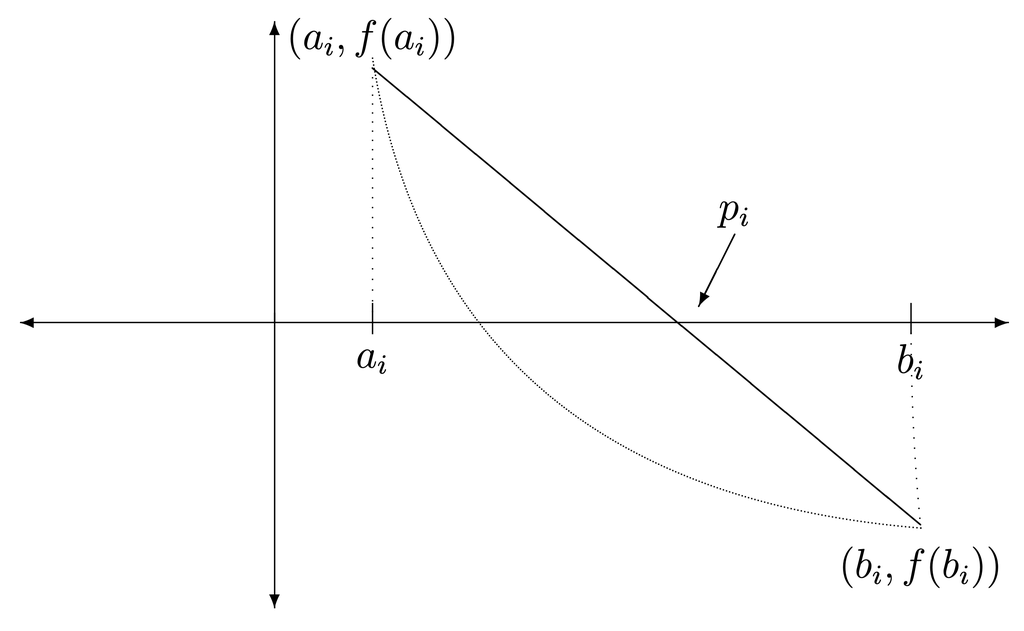

  2. Calcule la ecuación de la recta que pasa por $(a_i, f(a_i))$ y $(b_i, f(b_i))$.
  3. Pruebe que:
     $$p_i = \frac{a_i f(b_i) - b_i f(a_i)}{f(b_i) - f(a_i)}$$
  4. Escriba un algoritmo en pseudocódigo para el método *Regula Falsi*.
  5. Escriba una función en R para este algoritmo.

## Solución

**a.** El método **Regula Falsi** consiste en **trazar una línea recta entre los puntos extremos del intervalo $[a_i, b_i]$ sobre la curva de $f$** y hallar el punto en que esta recta intersecta el eje $x$. Ese punto se usa como una mejor aproximación a la raíz.

- Geométricamente, se asemeja al método de la **secante**, pero manteniendo la propiedad de que la raíz siempre queda contenida entre los extremos del intervalo.
- Luego se actualiza el intervalo según el signo de $f(p_i)$.

**b.** Ecuación de la recta que pasa por $(a_i, f(a_i))$ y $(b_i, f(b_i))$

La recta que pasa por dos puntos $(x_1, y_1)$ y $(x_2, y_2)$ tiene la forma:

$$y - y_1 = \frac{y_2 - y_1}{x_2 - x_1}(x - x_1)$$

Aplicando esto con:

- $x_1 = a_i$, $y_1 = f(a_i)$
- $x_2 = b_i$, $y_2 = f(b_i)$

La ecuación de la recta es:

$$y - f(a_i) = \frac{f(b_i) - f(a_i)}{b_i - a_i}(x - a_i)$$

**c.** Buscamos el punto de intersección con el eje $x$ (i.e., donde $y = 0$):

$$\begin{align*}
0 - f(a_i) &= \frac{f(b_i) - f(a_i)}{b_i - a_i}(p_i - a_i) \\
\Rightarrow -f(a_i)(b_i - a_i) &= (f(b_i) - f(a_i))(p_i - a_i) \\
\Rightarrow p_i - a_i &= \frac{-f(a_i)(b_i - a_i)}{f(b_i) - f(a_i)} \\
\Rightarrow p_i &= a_i - \frac{f(a_i)(b_i - a_i)}{f(b_i) - f(a_i)}
\end{align*}$$

Multiplicando y dividiendo, obtenemos una forma simétrica:

$$p_i = \frac{a_i f(b_i) - b_i f(a_i)}{f(b_i) - f(a_i)}$$

**d)** Pseudocódigo del método Regula Falsi

```
Entrada: f, a, b, tol, Nmax

Si f(a) * f(b) ≥ 0 entonces
    Detener: no se garantiza una raíz en [a, b]
Fin si

Para i desde 1 hasta Nmax hacer:
    Calcular:
        p ← (a * f(b) - b * f(a)) / (f(b) - f(a))

    Si |f(p)| < tol entonces
        Retornar p
    Fin si

    Si f(p) * f(a) < 0 entonces
        b ← p
    Sino
        a ← p
    Fin si
Fin para

Retornar error: no se alcanzó la tolerancia deseada
```

**e)** Implementación en R

**Código**

```r
regula_falsi <- function(f, a, b, tol = 1e-6, Nmax = 100) {
  if (f(a) * f(b) >= 0) {
    stop("No se garantiza una raíz en el intervalo [a, b].")
  }

  for (i in 1:Nmax) {
    fa <- f(a)
    fb <- f(b)
    p <- (a * fb - b * fa) / (fb - fa)

    if (abs(f(p)) < tol) {
      cat("Iteraciones:", i, "\n")
      return(p)
    }

    if (f(p) * fa < 0) {
      b <- p
    } else {
      a <- p
    }
  }

  stop("No se alcanzó la tolerancia deseada en el número máximo de iteraciones.")
}
```

Ejemplo de uso

```r
f <- function(x) x^3 - x - 2
raiz <- regula_falsi(f, 1, 2, tol = 1e-6)
```

```
Iteraciones: 13
```

```r
print(raiz)
```

```
[1] 1.52138
```

# Ejercicio 12

**Instrucción**

Use el método de *Regula Falsi* para aproximar la solución de las siguientes ecuaciones con 6 dígitos significativos, determine el intervalo inicial gráficamente. Compare los resultados con los que se obtienen usando directamente **R**.

1. $\log(1 + x) - x^2 = 0$
2. $x^3 + 2x - 1 = 0$

## Solución

```r
f1 <- function(x) log(1 + x) - x^2
f2 <- function(x) x^3 + 2*x - 1
```

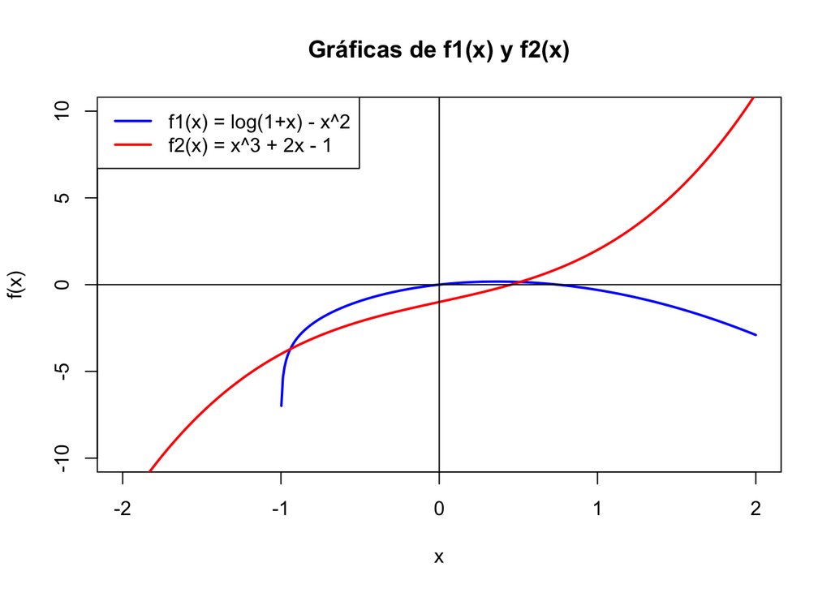

```r
x <- seq(-2, 2, length.out = 400)

# Evaluar funciones
y1 <- f1(x)
y2 <- f2(x)

# Graficar f1
plot(x, y1, type = "l", col = "blue", lwd = 2,
     ylim = c(-10, 10),
     xlab = "x", ylab = "f(x)",
     main = "Gráficas de f1(x) y f2(x)")

# Agregar f2
lines(x, y2, col = "red", lwd = 2)

# Ejes
abline(h = 0, v = 0, col = "black")

# Leyenda
legend("topleft",
       legend = c("f1(x) = log(1+x) - x^2",
                  "f2(x) = x^3 + 2x - 1"),
       col = c("blue", "red"), lwd = 2)
```

A partir del gráfico se puede observar que f1 interseca con el eje x en dos puntos: uno parece estar entre -0.5 y 0.5, mientras el otro parece estar entre0.5 y 1.

Por otra parte, f2 parece intersecar entre 0 y 1 a)

```r
regula.falsi(-0.5, 0.5, 1e-6, 100, f1)
```

```
$valor
[1] 4.100353e-18

$iteraciones
[1] 50
```

```r
#Calculo con R
raiz.a.1 <- uniroot(f1, c(-0.5,0.5))$root
sprintf("%.20f", raiz.a.1)
```

```
[1] "0.00000108466331270529"
```

```r
regula.falsi(0.5, 1, 1e-6, 100, f1)
```

```
$valor
[1] 0.7468817

$iteraciones
[1] 26
```

```r
#Calculo con R
raiz.a.2 <- uniroot(f1, c(0.5,1))$root
sprintf("%.20f", raiz.a.2)
```

```
[1] "0.74687960898323879633"
```

```r
regula.falsi(0,1,1e-6, 100,f2)
```

```
$valor
[1] 0.4533977

$iteraciones
[1] 30
```

```r
#Calculo con R
raiz.b <- uniroot(f2, c(0,1))$root
sprintf("%.20f", raiz.b)
```

```
[1] "0.45339750274672485642"
```

# Ejercicio 13

**Instrucción**

Pruebe que la sucesión construida por:

$$x_{n+1} =
\begin{cases}
1 & \text{si } n = 0 \\
\dfrac{a + (m - 1)x_n^m}{m x_n^{m-1}} & \text{si } n \geq 1
\end{cases}$$

converge a $\sqrt[m]{a}$, con $a > 0$.

## Solución

Note que calcular $\sqrt[m]{a}$ es equivalente a resolver la ecuación:

$$x^m - a = 0$$

Aplicando el método de Newton–Raphson con $f(x) = x^m - a$, tenemos:

$$f'(x) = m x^{m-1}$$

Entonces, la fórmula de Newton–Raphson es:

$$\begin{align*}
x_{n+1} &= x_n - \frac{x_n^m - a}{m x_n^{m-1}} \\
&= \frac{m x_n^m - (x_n^m - a)}{m x_n^{m-1}} \\
&= \frac{a + (m - 1)x_n^m}{m x_n^{m-1}}
\end{align*}$$

Esto coincide exactamente con la fórmula de recurrencia dada para $n \geq 1$.

Por lo tanto, como la sucesión está construida con el método de Newton–Raphson para una función que cumple las condiciones del teorema de convergencia de Newton, sabemos que esta sucesión converge a la solución de $x^m - a = 0$, la cual es:

$$\sqrt[m]{a}$$

$\blacksquare$

# Ejercicio 14

**Instrucción**

Demuestre que las siguientes sucesiones $(x_n)$ convergen linealmente a $x = 0$. Encuentre cuántos términos deben generarse antes de que $|x_n - x| \leq 5 \times 10^{-2}$.

1. $x_n = \dfrac{1}{n}$, $n \geq 0$
2. $x_n = \dfrac{1}{n^2}$, $n \geq 0$

## Solución

**Prueba a)**

$x_n=\frac{1}{n}$

**Convergencia a $0$.** Vea que como $\lim\limits_{n\to\infty}\frac{1}{n}=0$, la sucesión converge a $x=0$.

Tomando $x_n=\frac{1}{n}$,
$$\frac{x_{n+1}}{x_n}=\frac{1/(n+1)}{1/n}=\frac{n}{n+1}\xrightarrow[n\to\infty]{}1$$
Vea entonces que $\lim\limits_{n\to\infty}\frac{|x_{n+1-0}|}{|x_n-0|^1} = 1>0$ lo que implica convergencia lineal.

**Tolerancia:** $|x_n|\le 5\times 10^{-2}$
$$\frac{1}{n}\le 0.05 \;\;\Longleftrightarrow\;\; n\ge 20.$$
Se requieren **$n=20$** (el término 20 ya cumple la cota).

**Prueba b)**

$x_n=\frac{1}{n^2}$

**Convergencia a $0$.**

Note que $\lim\limits_{n\to\infty}\frac{1}{n^2}=0$.

Con $x_n=\frac{1}{n^2}$,
$$\frac{x_{n+1}}{x_n}=\frac{1/(n+1)^2}{1/n^2}=\Big(\frac{n}{n+1}\Big)^2\xrightarrow[n\to\infty]{}1$$
**Tolerancia $|x_n|\le 5\times 10^{-2}$.**
$$\frac{1}{n^2}\le 0.05 \;\;\Longleftrightarrow\;\; n\ge \sqrt{20}\approx 4.472.$$
Por lo tanto, basta con **$n=5$**.

- Ambas sucesiones **convergen linealmente a $0$**
- Para cumplir $|x_n|\le 5\times 10^{-2}$:
  - $x_n=\frac{1}{n}$: **$n\ge 20$**.
  - $x_n=\frac{1}{n^2}$: **$n\ge 5$**.

# Ejercicio 15

**Instrucción**

Demuestre que la sucesión definida por $x_n = 1/n^k$, $n \geq 1$, para cualquier entero positivo $k$, converge linealmente a $x = 0$. Para cada par de enteros $k$ y $m$, determinar un número $N$ para el cual $1/N^k < 10^{-m}$.

## Solución

Sea $x_n = \dfrac{1}{n^k}$ para $k \in \mathbb{Z}^+$.

Queremos verificar si la sucesión converge **linealmente** a $x = 0$.

Calculamos:

$$\lim_{n \to \infty} \frac{|x_{n+1} - x|}{|x_n - x|} = \lim_{n \to \infty} \frac{\frac{1}{(n+1)^k}}{\frac{1}{n^k}} = \lim_{n \to \infty} \left(\frac{n}{n+1}\right)^k = 1$$

Por lo tanto, $x_n$ converge linealmente a $0$ con constante asintótica $\lambda = 1$ (o más estrictamente, con $\lambda \lesssim 1$ pero **no estrictamente menor** que 1).

Como el cociente tiende a 1, se puede decir que la convergencia es **sub-lineal** si se requiere $\lambda < 1$, pero para fines prácticos de velocidad de convergencia, se considera **lineal lenta**.

Sean $k, m \in \mathbb{Z}^+$, queremos:

$$\frac{1}{N^k} < 10^{-m}
\quad \Leftrightarrow \quad
N^k > 10^m
\quad \Leftrightarrow \quad
N > \sqrt[k]{10^m} = 10^{\frac{m}{k}}$$

Por lo tanto, basta tomar:

$$N = \left\lceil 10^{\frac{m}{k}} \right\rceil$$

donde $\lceil \cdot \rceil$ denota el **techo entero** (menor entero mayor o igual que el número).

# Ejercicio 16

**Instrucción**

Demostrar que la sucesión $x_n = 10^{-2^n}$ converge cuadráticamente a cero.

## Solución

Hay que demostrar que existe $\lambda$ positiva, tal que:

$$\lim_{n \to \infty} \frac{|x_{n+1} - 0|}{|x_n - 0|^2} = \lambda,$$
$$\begin{align*}
\lim_{n\to\infty}\frac{|x_{n+1}-0|}{|x_n-0|^2}
&= \lim_{n\to\infty}\frac{|10^{-2^{\,n+1}}|}{|10^{-2^{\,n}}|^{2}} \\
&= \lim_{n\to\infty}\frac{10^{-2^{\,n+1}}}{\big(10^{-2^{\,n}}\big)^{2}}
= \lim_{n\to\infty}\frac{10^{-2\cdot 2^{\,n}}}{10^{-2\cdot 2^{\,n}}}
= 1>0
\end{align*}$$

Por lo tanto, $\lambda=1>0$ y la sucesión converge cuadráticamente a $0$.

# Ejercicio 17

**Instrucción**

Para las siguientes sucesiones $(x_n)$, linealmente convergentes, use el método $\Delta^2$ de Aitken para generar una sucesión $(\bar{x}_n)$ hasta que $|\bar{x}_n - x| \leq 5 \times 10^{-2}$.

1. $x_n = \dfrac{1}{n}$, $n \geq 0$
2. $x_n = \dfrac{1}{n^2}$, $n \geq 0$

## Solución

**Caso a)**
$$x_n = \tfrac{1}{n}$$

Empezamos por los términos de la sucesión:
$$x_n = \frac{1}{n}, \quad x_{n+1} = \frac{1}{n+1}, \quad x_{n+2} = \frac{1}{n+2}$$

Calculamos sus diferencias:
$$\Delta x_n = -\frac{1}{n(n+1)},
\qquad
\Delta^2 x_n = \frac{2}{n(n+1)(n+2)}$$

La Transformada resulta en:
$$\bar{x}_n
= \frac{1}{n} - \frac{\left(-\tfrac{1}{n(n+1)}\right)^2}{\tfrac{2}{n(n+1)(n+2)}}
= \frac{1}{2(n+1)}$$

Verificando la condición del error:
$$\left|\bar{x}_n\right| = \frac{1}{2(n+1)} \leq 0.05
\quad \Rightarrow \quad n \geq 9$$

Se cumple desde $n=9$.

**Caso b)**

$$x_n = \tfrac{1}{n^2}$$

Empezamos por los términos de la sucesión:
$$x_n = \frac{1}{n^2}, \quad x_{n+1} = \frac{1}{(n+1)^2}, \quad x_{n+2} = \frac{1}{(n+2)^2}$$

Tras un proceso similar al ejercicio anterior, la simplificación para $\bar{x}$:
$$\bar{x}_n = \frac{1}{(n+1)(n+2)}.$$

Verificando la condición:
$$\left|\bar{x}_n\right| = \frac{1}{(n+1)(n+2)} \leq 0.05.$$

Si evaluamos en $n=3$:
$$\bar{x}_3 = \frac{1}{4 \cdot 5} = 0.05.$$

Por lo que cumple desde $n=3$.

# Ejercicio 18

**Instrucción**

Un conocido método numérico para minimizar funciones *estrictamente unimodales* (una función $f$ que decrece estrictamente (o crece estrictamente) hasta su punto mínimo (máximo)) se llama la función estrictamente unimodal en un intervalo $[a, b]$, y uno de ellos es el **Método Igualmente Espaciado**. La idea geométrica se ilustra en el siguiente gráfico:

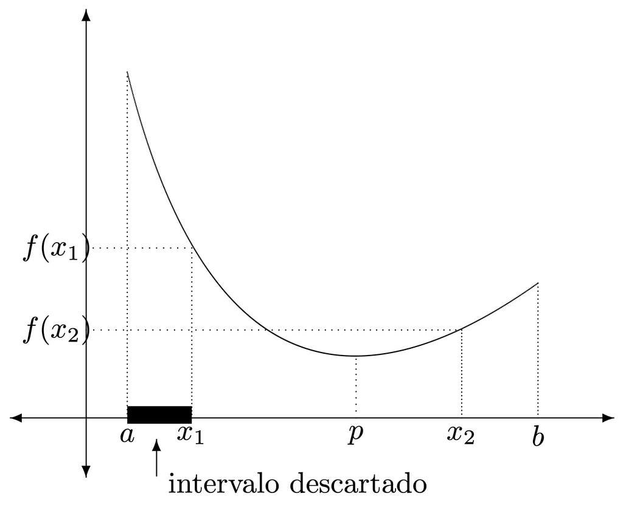

Se toma $a_1 = a$ y $b_1 = b$, y además:
$$x_1 := \frac{2a + b}{3}, \qquad x_2 := \frac{a + 2b}{3}$$

Entonces, como se ilustra en el gráfico:

- Si $f(x_1) > f(x_2)$, entonces se toma:
  $$a_2 = x_1, \quad b_2 = b_1, \quad p_1 = a_2$$
  y el nuevo intervalo es:
  $$[a_2, b_2] = [x_1, b_1] = \left[ \frac{2a + b}{3}, b \right]$$
- En caso contrario, se toma:
  $$a_2 = a_1, \quad b_2 = x_2, \quad p_1 = b_2$$
  y el nuevo intervalo es:
  $$[a_2, b_2] = [a_1, x_2] = \left[ a_1, \frac{a + 2b}{3} \right]$$

Con el nuevo intervalo se aplica el proceso de nuevo, y así sucesivamente hasta que $a_n$ y $b_n$ estén suficientemente cerca. La sucesión $(p_n)$ converge al punto $p$ donde $f$ alcanza el mínimo.

1. De acuerdo con lo anterior, pruebe que $x_1 < x_2$.
2. Construya un algoritmo en pseudocódigo y la correspondiente función en **R** para el método *Igualmente Espaciado* descrito anteriormente.
3. Pruebe que el intervalo construido con el algoritmo anterior satisface la relación:
   $$|b_n - a_n| \leq \left( \frac{2}{3} \right)^{n-1} (b - a)$$

¿Qué se puede concluir, respecto al error absoluto?

4. ¿Cuántas iteraciones se requieren teóricamente para minimizar la función $f(x) = x^4 - 4x^3 + 3x^2$ en el intervalo $[1, 4]$ si se desea un error absoluto menor a $10^{-5}$? Encuentre el mínimo.

## Solución

1. Sabemos que $a < b$
   $$\begin{align*}
   &\Rightarrow 2a < b + a \\
   &\Rightarrow 2a + b < 2b + a \\
   &\Rightarrow \frac{2a + b}{3} < \frac{2b + a}{3} \\
   &\Rightarrow x_1 < x_2
   \end{align*}$$

**Código**

```r
ig.espaciado <- function(a, b, tol, n, f) {
  i <- 1
  a.temp <- a
  b.temp <- b
  while (i <= n) {
    x1 <- (2 * a.temp + b.temp) / 3
    x2 <- (a.temp + 2 * b.temp) / 3
    if (f(x1) > f(x2)) {
      a.temp <- x1
      x <- a.temp
    }
    else{
      b.temp <- x2
      x <- b.temp
    }
    if (abs(b.temp - a.temp) < tol) {
      return(list("valor" = x, "iteraciones" = i))
    }
    i <- i + 1
  }
  return(NULL)
}
```

3. Queremos probar que el intervalo construido con el algoritmo anterior satisface:

$$|b_n - a_n| \leq \left(\frac{2}{3}\right)^{n-1}(b - a)$$

$$\begin{align*}
|b_1 - a_1| &= |b - a| \\
|b_2 - a_2| &= \left(\frac{2}{3}\right)|b - a| \\
|b_3 - a_3| &= \left(\frac{2}{3}\right)^2 |b - a| \\
&\vdots \\
|b_n - a_n| &= \left(\frac{2}{3}\right)^{n-1}|b - a|
\end{align*}$$

Como $x_n \in ]a_n, b_n[$ y $x_n = \frac{2a_n + b_n}{3}$ o $x_n = \frac{a_n + 2b_n}{3}$

Entonces:
$$\begin{align*}
|x_n - x| &\leq \frac{2}{3}|b_n - a_n| \leq \frac{2}{3} \left(\frac{2}{3}\right)^{n-1} |b - a| \\
&= \left(\frac{2}{3}\right)^n |b - a|
\end{align*}$$

$\blacksquare$

4. Queremos que:

$$|x_n - x| \leq \left(\frac{2}{3}\right)^n \cdot 3 < 10^{-5}$$

$$\begin{align*}
\left(\frac{2}{3}\right)^n &< 10^{-5} \cdot 3 \\
n &> \frac{\ln(10^{-5} \cdot 3)}{\ln\left(\frac{2}{3}\right)} \approx 31.10 \\
\Rightarrow n &\geq 32 \text{ iteraciones}
\end{align*}$$

El valor mínimo de la función se obtiene de la siguiente manera.

```r
f <- function(x) x^4 - 4*x^3 +3*x^2
f(ig.espaciado(1, 4, 1e-5, 1000, f)$valor)
```

```
[1] -4.848076
```

$\blacksquare$

# Ejercicio 19

**Instrucción**

En este ejercicio se presenta el **Método Dicotómico** para minimizar funciones estrictamente unimodales. En este método primeramente se evalúa la función $f(x)$ en dos puntos que están a una distancia de $\varepsilon/2$ del punto medio del intervalo $[a, b]$, es decir se calculan:

$$f\left( \frac{a + b - \varepsilon}{2} \right) \quad \text{y} \quad f\left( \frac{a + b + \varepsilon}{2} \right),$$

y se procede a compararlos. Si

### a)

$$f\left( \frac{a + b - \varepsilon}{2} \right) \leq f\left( \frac{a + b + \varepsilon}{2} \right),$$

entonces se descarta el intervalo $\left] \frac{a + b + \varepsilon}{2}, b \right]$ y así el punto mínimo $x^*$ debe estar en el intervalo $\left[a, \frac{a + b + \varepsilon}{2} \right],$ el cual será el nuevo intervalo de búsqueda.

Si

$$f\left( \frac{a + b - \varepsilon}{2} \right) > f\left( \frac{a + b + \varepsilon}{2} \right),$$

entonces se descarta el intervalo $\left[a, \frac{a + b - \varepsilon}{2} \right[$ y en este caso el punto mínimo $x^*$ debe estar en el intervalo $\left[ \frac{a + b - \varepsilon}{2}, b \right].$

Pruebe que en cualquiera de los casos la longitud del intervalo de búsqueda se reduce de $b - a$ a $\frac{b - a + \varepsilon}{2}.$

### b)

Suponga que se tiene el caso:

$$f\left( \frac{a + b - \varepsilon}{2} \right) \leq f\left( \frac{a + b + \varepsilon}{2} \right),$$

entonces se descarta el intervalo $\left] \frac{a + b + \varepsilon}{2}, b \right]$, y el nuevo intervalo de búsqueda es $\left[ a, \frac{a + b + \varepsilon}{2} \right].$

Ahora se debe calcular:

$$f\left( \frac{3a + b - \varepsilon}{4} \right) \quad \text{y} \quad f\left( \frac{3a + b + 3\varepsilon}{4} \right),$$

y surgen de nuevo dos posibilidades. Si

$$f\left( \frac{3a + b - \varepsilon}{4} \right) \leq f\left( \frac{3a + b + 3\varepsilon}{4} \right),$$

entonces se descarta el intervalo $\left] \frac{3a + b + 3\varepsilon}{4}, \frac{a + b + \varepsilon}{2} \right]$ y el nuevo intervalo de búsqueda es $\left[a, \frac{3a + b + 3\varepsilon}{4} \right]$. En el otro caso se descarta el intervalo $\left[a, \frac{3a + b - \varepsilon}{4} \right]$ y el nuevo intervalo de búsqueda es $\left[ \frac{3a + b - \varepsilon}{4}, \frac{a + b + \varepsilon}{2} \right].$

Pruebe que en cualquiera de los casos la longitud del intervalo de búsqueda se reduce de $\frac{b - a + \varepsilon}{2}$ a $\frac{b - a + 3\varepsilon}{4}.$

### c)

Repitiendo el proceso $n$ veces deben calcularse:

$$f\left( \frac{(2^n - 1)a + b - \varepsilon}{2^n} \right) \quad \text{y} \quad f\left( \frac{(2^n - 1)a + b + (2^n - 1)\varepsilon}{2^n} \right),$$

pruebe que en cualquiera de los dos casos la longitud del intervalo de búsqueda es

$$\frac{b - a + (2^n - 1)\varepsilon}{2^n}.$$

Con lo cual, si $x_n$ representa la $n$-ésima aproximación del punto mínimo $x^*$, entonces pruebe que:

$$|x^* - x_n| \leq \frac{b - a + (2^n - 1)\varepsilon}{2^n}.$$

El proceso se ilustra en la Figuras 1 y 2.

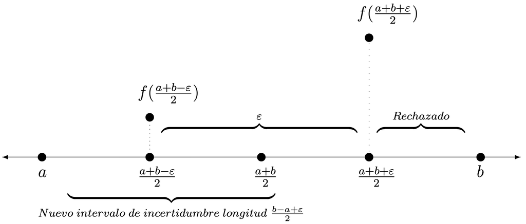

Figura 1

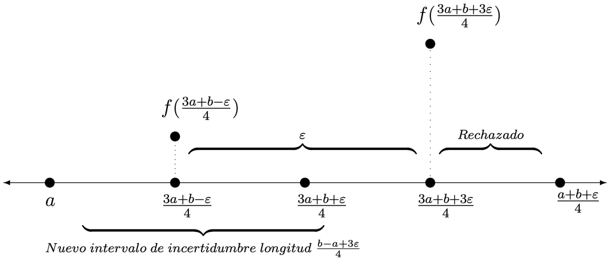

Figura 2

### d)

Construya un algoritmo en pseudocódigo y la correspondiente función **R** para el *Método Dicotómico* descrito anteriormente.

### e)

¿Cuántas iteraciones se requieren teóricamente para minimizar
$$f(x) = x^4 - 4x^3 + 3x^2$$
en el intervalo $[1, 4]$ si se desea que el resultado tenga un error absoluto menor a $10^{-5}$?

Encuentre el mínimo.

## Solución

Sea $f$ estrictamente unimodal en $[a,b]$. En el **método dicotómico** se evalúa $f$ en los dos puntos a distancia $\varepsilon/2$ del punto medio:
$$x_1=\frac{a+b-\varepsilon}{2},\qquad
x_2=\frac{a+b+\varepsilon}{2},$$

**Prueba a)**

Como $f$ es estrictamente unimodal, si $f(x_1)\le f(x_2)$ el mínimo $x^\star$ no puede estar a la derecha de $x_2$; si $f(x_1)>f(x_2)$, $x^\star$ no puede estar a la izquierda de $x_1$. Por ello es válido descartar, respectivamente, los subintervalos indicados.

**Caso (a)**: $f(x_1)\le f(x_2)$.

El nuevo intervalo es $[a,\tfrac{a+b+\varepsilon}{2}]$. Su longitud es
$$\begin{align*}
\Bigg(\frac{a+b+\varepsilon}{2}\Bigg)-a
&= \frac{a+b+\varepsilon-2a}{2}
= \frac{b-a+\varepsilon}{2}.
\end{align*}$$

**Caso (b)**: $f(x_1)>f(x_2)$.

El nuevo intervalo es $\left[\,\tfrac{a+b-\varepsilon}{2},\,b\,\right]$. Su longitud es
$$\begin{align*}
b-\Bigg(\frac{a+b-\varepsilon}{2}\Bigg)
&= \frac{2b-a-b+\varepsilon}{2}
= \frac{b-a+\varepsilon}{2}.
\end{align*}$$

En ambos casos la longitud pasa de $b-a$ a $\dfrac{b-a+\varepsilon}{2}$.

Una iteración del método dicotómico reduce el tamaño del intervalo de búsqueda desde $b-a$ hasta
$$\frac{b-a+\varepsilon}{2},$$
manteniendo dentro del nuevo intervalo al punto de mínimo $x^\star$. Reiterando el procedimiento se obtiene una secuencia de intervalos que contienen $x^\star$ y cuyas longitudes decrecen geométricamente (con corrección $\varepsilon$). $\square$

**Prueba b)**

Volvemos a tener dos posibilidades:

Caso 1: $f(x_3)\le f(x_4)$

Se descarta el subintervalo $\left]\tfrac{3a+b+3\varepsilon}{4},\;\tfrac{a+b+\varepsilon}{2}\right]$ y el nuevo intervalo es
$$I_2=\left[a,\;\frac{3a+b+3\varepsilon}{4}\right].$$

**Longitud**:
$$\begin{align*}
|I_2|
&=\frac{3a+b+3\varepsilon}{4}-a
=\frac{3a+b+3\varepsilon-4a}{4}
=\frac{b-a+3\varepsilon}{4}.
\end{align*}$$

Caso 2: $f(x_3)> f(x_4)$

Se descarta el subintervalo $\left[a,\;\tfrac{3a+b-\varepsilon}{4}\right]$ y el nuevo intervalo es
$$I_2=\left[\frac{3a+b-\varepsilon}{4},\;\frac{a+b+\varepsilon}{2}\right].$$

**Longitud**:
$$\begin{align*}
|I_2|
&=\frac{a+b+\varepsilon}{2}-\frac{3a+b-\varepsilon}{4}
=\frac{2a+2b+2\varepsilon-3a-b+\varepsilon}{4}
=\frac{b-a+3\varepsilon}{4}.
\end{align*}$$

Tras la primera evaluación, la longitud había pasado de $b-a$ a $\dfrac{b-a+\varepsilon}{2}$. Después de la segunda evaluación (dentro del mismo caso b) ), **en cualquiera de las dos comparaciones** la longitud del intervalo se reduce a
$$\frac{b-a+3\varepsilon}{4}.$$

La unimodalidad estricta garantiza en ambos casos que el punto de mínimo $x^\star$ permanece dentro del nuevo intervalo.

**Prueba c)**

Procederemos por inducción

Caso Base $n=1$.
$$L_1=\frac{b-a+\varepsilon}{2}=\frac{b-a+(2^1-1)\varepsilon}{2^1}.$$

Paso inductivo. Suponga que
$$L_k=\frac{b-a+(2^k-1)\varepsilon}{2^k}.$$
Entonces, usando $L_{k+1}=T(L_k)=\dfrac{L_k+\varepsilon}{2}$,
$$\begin{align*}
L_{k+1}
&=\frac{1}{2}\left(\frac{b-a+(2^k-1)\varepsilon}{2^k}+\varepsilon\right)\\
&=\frac{b-a+(2^k-1)\varepsilon+2^k\varepsilon}{2^{k+1}}
=\frac{b-a+(2^{k+1}-1)\varepsilon}{2^{k+1}}.
\end{align*}$$
Queda demostrada por inducción la expresión
$$\boxed{\,L_n=\dfrac{b-a+(2^n-1)\varepsilon}{2^n}\, }.$$

En cada iteración, el mínimo $x^\star$ permanece dentro del intervalo de búsqueda y la aproximación $x_n$ también se toma dentro de ese intervalo. Por lo tanto, la distancia entre ambos no excede la **longitud** del intervalo vigente:
$$|x^\star-x_n|\le L_n
=\frac{b-a+(2^n-1)\varepsilon}{2^n}.$$

El método dicotómico reduce la longitud del intervalo según
$$L_n=\frac{b-a+(2^n-1)\varepsilon}{2^n},$$
y garantiza la cota de error
$$\boxed{\,|x^\star-x_n|\le \dfrac{b-a+(2^n-1)\varepsilon}{2^n}\, } \qquad \square$$

**Código**

```r
dicotomico <- function(a, b, e, tol, n, f) {
  i <- 1
  a.temp <- a
  b.temp <- b
  while (i <= n) {
    x1 <- (a.temp + b.temp - e)/2
    x2 <- (a.temp + b.temp + e)/2
    if(f(x1) <= f(x2)){
      b.temp <- x2
      x <- b.temp
    }
    else{
      a.temp <- x1
      x <- a.temp
    }
    if(abs(b.temp - a.temp) < tol){
      return(list("valor" = x, "iteraciones" = i))
    }
    i <- i+1
  }
  return(NULL)
}
```

```r
f <- function(x) x^4 -4*x^3 + 3*x^2

min.x <- dicotomico(1, 4, 1e-6, 1e-5, 100, f)
min.x
```

```
$valor
[1] 2.36603

$iteraciones
[1] 19
```

Para encontrar el valor minimo de la funcion en [1,4], esta se evalua en el punto encontrado recientemente:

```r
f(min.x$valor)
```

```
[1] -4.848076
```

# Ejercicio 20

**Instrucción**

El objetivo de este ejercicio es demostrar la convergencia del método de Newton–Raphson sin utilizar el Teorema de punto fijo de Banach.

**Teorema:** Sea $f \in C^2[a, b]$. Si $x \in [a, b]$ con $f(x) = 0$ y $f'(x) \neq 0$, entonces existe $\varepsilon > 0$ tal que el método de Newton–Raphson:
$$x_{n+1} := x_n - \frac{f(x_n)}{f'(x_n)}$$
genera una sucesión que está bien definida y converge a $x$ cuando $n \to \infty$, para todo $x_0 \in [x - \varepsilon, x + \varepsilon]$.

Para esto haga lo siguiente:

1. Pruebe que si $(r_n)_{n \geq 0}$ es una sucesión de números positivos o nulos que verifican:
   $$r_{n+1} \leq r_n^2,$$
   y si $r_0 < 1$, entonces $(r_n)$ converge a 0. Además, pruebe que:
   $$r_n \leq (r_0)^{2^n}.$$
2. Pruebe que:

$$x_{n+1} - x = \frac{(x_n - x)f'(x_n) - f(x_n) + f(x)}{f'(x_n)}. \tag{1}$$

3. Pruebe que existen números estrictamente positivos $\epsilon_1$ y $M$ tales que:

$$\text{para todo } y \in [x - \epsilon_1, x + \epsilon_1] \text{ se tiene que } |f'(y)| \geq M.$$

4. Justifique por qué:

$$\max_{y \in [x - \epsilon_1, x + \epsilon_1]} |f''(y)| := L < \infty.$$

5. Pruebe que el valor absoluto de la parte derecha del numerador de la ecuación (1) es igual a:

$$\left| \int_{x_n}^{x} f''(t)(x - t) \, dt \right|. \tag{2}$$

6. Pruebe que (2) está acotado por:

$$\frac{L}{2} |x_n - x|^2.$$

7. Pruebe que si se define

$$r_n := \frac{L}{2M} |x_n - x|
\quad \text{entonces} \quad
r_{n+1} \leq r_n^2.$$

8. Sea $\epsilon = \min\left(\epsilon_1, \frac{2M}{L} \right)$, pruebe que si $|x_n - x| < \epsilon$, entonces use la parte (a) para probar que $|x_{n+1} - x| < \epsilon$, y concluya el resultado.

## Solución

1. Se va a probar por inducción que $r_n \leq (r_0)^{2^n}$.

**Caso base**: $n = 1$.

Se tiene que $r_1 \leq r_0^2$, lo cual es cierto porque la sucesión cumple que:

$$r_{n+1} \leq r_n^2$$

**Paso inductivo**: Suponga que $r_n \leq (r_0)^{2^n}$. Queremos probar que $r_{n+1} \leq (r_0)^{2^{n+1}}$.

Por la hipótesis inductiva:

$$\begin{align*}
r_n &\leq (r_0)^{2^n} \\
\Rightarrow r_n^2 &\leq \left( (r_0)^{2^n} \right)^2 = (r_0)^{2^{n+1}}
\end{align*}$$

Y dado que $r_{n+1} \leq r_n^2$, entonces:

$$r_{n+1} \leq (r_0)^{2^{n+1}} \quad \blacksquare$$

**Para demostrar convergencia a $0$**, observamos que si $0 < r_0 < 1$, entonces:

$$(r_0)^{2^n} \to 0 \quad \text{cuando } n \to \infty$$

y como $0 \leq r_n \leq (r_0)^{2^n}$, se concluye que:

$$r_n \to 0 \quad \text{cuando } n \to \infty \quad \blacksquare$$

2. Queremos demostrar:

$$x_{n+1} - x = \frac{(x_n - x) f'(x_n) - f(x_n) + f(x)}{f'(x_n)}$$

Pero como $f(x) = 0$, se tiene:

$$\begin{align*}
x_{n+1} - x &= x_n - \frac{f(x_n)}{f'(x_n)} - x \\
&= \frac{f'(x_n)x_n - f(x_n)}{f'(x_n)} - x \\
&= \frac{f'(x_n)x_n - f(x_n) - f'(x_n)x}{f'(x_n)} \\
&= \frac{f'(x_n)(x_n - x) - f(x_n)}{f'(x_n)} \\
&= \frac{(x_n - x) f'(x_n) - f(x_n)}{f'(x_n)} \quad \blacksquare
\end{align*}$$

3. Queremos probar que existen $\epsilon_1 > 0$ y $M > 0$ tales que:

$$\forall y \in [x - \epsilon_1, x + \epsilon_1] \Rightarrow |f'(y)| \geq M$$

Dado que $f'(x) \neq 0$ y $f'$ es continua, existe un $\epsilon_1 > 0$ tal que:

$$f'(y) \neq 0 \quad \forall y \in [x - \epsilon_1, x + \epsilon_1]$$

Esto implica que:

$$M := \inf_{y \in [x - \epsilon_1, x + \epsilon_1]} |f'(y)| > 0 \quad \blacksquare$$
d) Queremos justificar que:

$$\max_{y \in [x - \epsilon_1, x + \epsilon_1]} |f''(y)| := L < \infty$$

Dado que $f''(y)$ es continua en $[x - \epsilon_1, x + \epsilon_1]$, un intervalo cerrado, alcanza un máximo en ese intervalo. Por lo tanto:

$$L := \max_{y \in [x - \epsilon_1, x + \epsilon_1]} |f''(y)| < \infty \quad \blacksquare$$
e) Queremos probar que el valor absoluto de la parte derecha del numerador de la ecuación (1) es igual a:

$$\left| \int_{x_n}^x f''(t)(x - t) \, dt \right|$$

Notamos que:

$$\begin{align*}
f(x) - f(x_n) &= \int_{x_n}^x f'(t) \, dt \\
\Rightarrow f(x) - f(x_n) - f'(x_n)(x - x_n) &= \int_{x_n}^x f'(t) \, dt - f'(x_n)(x - x_n) \\
&= \int_{x_n}^x \left(f'(t) - f'(x_n)\right) dt \tag{★}
\end{align*}$$

Por otra parte, usando el teorema fundamental del cálculo:

$$\begin{align*}
f'(t) - f'(x_n) = \int_{x_n}^t f''(s) \, ds
\end{align*}$$

Sustituyendo en (★):

$$\begin{align*}
\int_{x_n}^x (f'(t) - f'(x_n)) dt &= \int_{x_n}^x \left( \int_{x_n}^t f''(s) \, ds \right) dt
\end{align*}$$

Intercambiamos el orden de integración (ver gráfica triangular en $s$-$t$):

$$\begin{align*}
\int_{x_n}^x \left( \int_{x_n}^t f''(s) \, ds \right) dt &= \int_{x_n}^x \left( \int_{s}^x dt \right) f''(s) \, ds \\
&= \int_{x_n}^x (x - s) f''(s) \, ds
\end{align*}$$

Entonces:

$$\begin{align*}
f(x) - f(x_n) - f'(x_n)(x - x_n) &= \int_{x_n}^x (x - s) f''(s) \, ds
\end{align*}$$

Haciendo cambio de variable $t = s$, se concluye:

$$\left| f(x) - f(x_n) - f'(x_n)(x - x_n) \right| = \left| \int_{x_n}^x f''(t)(x - t) \, dt \right| \quad \blacksquare$$

6. Probar que la expresión:

$$\left| \int_{x_n}^x f''(t)(x - t) \, dt \right|$$

está acotada por:

$$\frac{L}{2} |x_n - x|^2$$

Dado que:

$$\begin{align*}
\left| \int_{x_n}^x f''(t)(x - t) \, dt \right|
&\leq \int_{x_n}^x |f''(t)| \cdot |x - t| \, dt \\
&\leq L \int_{x_n}^x |x - t| \, dt
\end{align*}$$

Calculamos:

$$\begin{align*}
\int_{x_n}^x |x - t| \, dt &= \int_{x_n}^x (x - t) \, dt \\
&= \left[ x t - \frac{t^2}{2} \right]_{x_n}^x \\
&= \left( x^2 - \frac{x^2}{2} \right) - \left( x x_n - \frac{x_n^2}{2} \right) \\
&= \frac{x^2}{2} - x x_n + \frac{x_n^2}{2} \\
&= \frac{(x - x_n)^2}{2}
\end{align*}$$

Por tanto:

$$\left| \int_{x_n}^x f''(t)(x - t) \, dt \right| \leq \frac{L}{2} |x - x_n|^2 \quad \blacksquare$$

7. Probar que si se define:

$$r_n := \frac{L}{2M} |x_n - x|$$

entonces se cumple:

$$|x_{n+1} - x| \leq r_n^2$$

Sabemos que:

$$x_{n+1} - x = \frac{\int_{x_n}^x f''(t)(x - t) \, dt}{f'(x_n)}$$

Aplicando el resultado del ítem **(f)**:

$$\begin{align*}
|x_{n+1} - x| &\leq \frac{1}{|f'(x_n)|} \left| \int_{x_n}^x f''(t)(x - t) \, dt \right| \\
&\leq \frac{L}{2M} |x_n - x|^2
\end{align*}$$

Luego, si definimos $r_n = \dfrac{L}{2M} |x_n - x|$, entonces:

$$|x_{n+1} - x| \leq r_n^2 \quad \blacksquare$$

8. $$\varepsilon < \min\left\{ \varepsilon_1, \frac{2M}{L} \right\}$$

Probar que si $|x_n - x| < \varepsilon$, entonces $|x_{n+1} - x| < \varepsilon$, y concluir que la sucesión converge.

Sabemos que:

$$|x_{n+1} - x| \leq r_n^2 = \left( \frac{L}{2M} |x_n - x| \right)^2$$

Si $|x_n - x| < \varepsilon$, se tiene:

$$\begin{align*}
|x_{n+1} - x| &\leq \left( \frac{L}{2M} \right)^2 \varepsilon^2 \\
&< \left( \frac{L}{2M} \cdot \varepsilon \right) \\
&< \varepsilon
\end{align*}$$

Ya que $\varepsilon < \dfrac{2M}{L}$, entonces $\dfrac{L}{2M} \cdot \varepsilon < 1$, y por tanto $\left( \dfrac{L}{2M} \cdot \varepsilon \right)^2 < \varepsilon$.

Por lo tanto:

$$|x_{n+1} - x| < \varepsilon \quad \blacksquare$$

Esto demuestra que la sucesión generada por el método de Newton-Raphson converge.

# Ejercicio 21

**Instrucción**

Demuestre que en el caso de ceros de multiplicidad $m$, el **Método de Newton Modificado**:

$$x_{n+1} = x_n - m \frac{f(x_n)}{f'(x_n)}$$

es cuadráticamente convergente. Sugerencia: Use series de Taylor.

## Solución

**Prueba**

Como la raíz tiene multiplicidad $m$, existe una función $g$ de clase $C^1$ con $g(\alpha)\ne 0$ tal que
$$f(x)=(x-\alpha)^m\,g(x),\qquad
f'(x)=m(x-\alpha)^{m-1}g(x)+(x-\alpha)^m g'(x).$$

Denotemos el error $e_n:=x_n-\alpha$ y abreviemos $g_n:=g(\alpha+e_n)$, $g_n':=g'(\alpha+e_n)$. Entonces
$$\frac{f(x_n)}{f'(x_n)}
=\frac{e_n^m g_n}{e_n^{m-1}\big(m g_n+e_n g_n'\big)}
=e_n\,\frac{g_n}{m g_n+e_n g_n'}.$$

El paso de Newton modificado queda
$$e_{n+1}=x_{n+1}-\alpha
=e_n- m\,e_n\,\frac{g_n}{m g_n+e_n g_n'}
= e_n\!\left(1-\frac{m g_n}{m g_n+e_n g_n'}\right).$$

Escriba el denominador como $m g_n\!\left(1+\dfrac{e_n g_n'}{m g_n}\right)$; usando la expansión
$$\frac{1}{1+z}=1-z+z^2+O(z^3)\quad (z\to 0),$$
se obtiene
$$\frac{m g_n}{m g_n+e_n g_n'}
= 1-\frac{e_n g_n'}{m g_n}+O(e_n^2).$$
Sustituyendo en la expresión de $e_{n+1}$:
$$e_{n+1}
= e_n\!\left(1-\Big[1-\frac{e_n g_n'}{m g_n}+O(e_n^2)\Big]\right)
= \frac{g_n'}{m g_n}\,e_n^2+O(e_n^3).$$

Como $g$ es $C^1$ y $g(\alpha)\ne 0$, tenemos $g_n\to g(\alpha)$, $g_n'\to g'(\alpha)$ cuando $e_n\to 0$, y por tanto existe una constante
$$C=\frac{g'(\alpha)}{m\,g(\alpha)}$$
tal que
$$e_{n+1}= C\,e_n^2+O(e_n^3).$$

La relación de error $e_{n+1}=C e_n^2+O(e_n^3)$ muestra que el **método de Newton modificado es cuadráticamente convergente** para raíces de multiplicidad $m$.

> **Comentario.** Para $m=1$ (raíz simple) se recupera el Newton clásico con $e_{n+1}=\dfrac{f''(\alpha)}{2f'(\alpha)}e_n^2+O(e_n^3)$. Para $m\ge2$, el factor cuadrático es $C=\dfrac{g'(\alpha)}{m g(\alpha)}$, donde $f(x)=(x-\alpha)^m g(x)$ y $g(\alpha)\ne 0$.

# Ejercicio 22

**Instrucción**

El objetivo de este ejercicio es demostrar la convergencia del método de la **Secante** sin utilizar el Teorema de punto fijo de Banach.

**Teorema:**  
Sea $f$ una función de clase $C^2[a, b]$, con $a < b$. Si existe un punto $x$ tal que $f(x) = 0$ y $f'(x) \neq 0$, entonces existe un número $\varepsilon > 0$ tal que si $x_0$ y $x_1$ están dentro del intervalo $[x - \varepsilon, x + \varepsilon]$, la sucesión generada por el método de la secante

$$x_{n+1} = x_n - \frac{(x_n - x_{n-1})f(x_n)}{f(x_n) - f(x_{n-1})}$$

está bien definida dentro del intervalo $[x - \varepsilon, x + \varepsilon]$ y converge a $x$, cero de la ecuación $f(x) = 0$.

1. Sea $(r_n)$ una sucesión de números reales positivos tales que:
   $$r_{n+1} \leq r_n r_{n-1}$$
   Pruebe que si $r_0 < 1$ y $r_1 < 1$, entonces la sucesión $(r_n)$ está acotada por 1 y converge a 0. Además, pruebe que existe una constante $C$ tal que:
   $$r_n \leq C r^\rho,$$
   donde $r$ es un número estrictamente menor que 1, y
   $$\rho = \frac{1 + \sqrt{5}}{2} \approx 1.618.$$
2. Se denota:
   $$f[x_n, x_{n-1}] := \frac{f(x_n) - f(x_{n-1})}{x_n - x_{n-1}}$$
   pruebe que:
   $$f(x_n) = (x_n - x) f[x_n, x]$$
3. Pruebe que:
   $$x_{n+1} - x = (x_n - x) \cdot \frac{f[x_n, x_{n-1}] - f[x_n, x]}{f[x_n, x_{n-1}]}$$
4. Pruebe que:
   $$x_{n+1} - x = \frac{(x_n - x)(x_n - x_{n-1}) f[x_n, x_{n-1}, x]}{f[x_n, x_{n-1}]},$$
   donde:
   $$f[x_n, x_{n-1}, x] := \frac{f[x_n, x_{n-1}] - f[x_n, x]}{x_n - x}$$
5. Sea $[x - \epsilon_1, x + \epsilon_1]$ un intervalo sobre el cual $|f'(x)| \geq M$.
   Pruebe que si $x_n$ y $x_{n-1}$ están dentro del intervalo, entonces:
   $$|f[x_n, x_{n-1}]| \geq M$$
6. Sea $L$ la cota superior de $|f''|$ en el intervalo $[x - \epsilon_1, x + \epsilon_1]$. Pruebe que si $x_n$ y $x_{n-1}$ están dentro del intervalo, entonces:
   $$|f[x_n, x_{n-1}, x]| \leq \frac{L}{2}$$
7. Pruebe que:
   $$|x_{n+1} - x| \leq \frac{L}{2M} |x_n - x| \cdot |x_{n-1} - x|$$
8. Tome:
   $$r_n := \frac{L}{2M} |x_n - x|, \quad \text{y} \quad \varepsilon < \min\left( \epsilon_1, \frac{2M}{L} \right)$$
   usando (a), concluya que si $x_0$ y $x_1$ están dentro del intervalo $[x - \varepsilon, x + \varepsilon]$, entonces $x_n$ está dentro del intervalo para todo $n$, y $|x_n - x| \to 0$ cuando $n \to \infty$.

## Solución

1. Sea $(r_n)$ una sucesión de números reales positivos tales que

$$r_{n+1} \le r_n r_{n-1}.$$

**Prueba.**

1. Si $r_0<1$ y $r_1<1$, entonces por inducción $r_n\le 1$ para todo $n$.  
2. Usando los números de Fibonacci $F_n$, se obtiene:

$$r_n \le r_0^{F_{n-1}} r_1^{F_n}.$$

Como $F_n \sim \tfrac{1}{\sqrt{5}} \rho^n$ con $\rho=\tfrac{1+\sqrt{5}}{2}\approx 1.618$, resulta que

$$r_n \le C \,\tilde r^{\rho^n}, \qquad 0<\tilde r<1.$$

En particular, $r_n\to 0$ por comparación.

2. Definimos:

$$f[x_n,x_{n-1}] := \frac{f(x_n)-f(x_{n-1})}{x_n-x_{n-1}}.$$

Como $x$ es raíz de f, $f(x)=0$ y:

$$f[x_n,x] = \frac{f(x_n)-f(x)}{x_n-x} = \frac{f(x_n)}{x_n-x}.$$

Por lo tanto:

$$f(x_n)=(x_n-x)\,f[x_n,x].$$
c) De la fórmula del método de la secante:

$$x_{n+1}=x_n-\frac{f(x_n)}{f[x_n,x_{n-1}]},$$

restando $x$ y usando (b):

$$x_{n+1}-x = (x_n-x)\,\frac{f[x_n,x_{n-1}]-f[x_n,x]}{f[x_n,x_{n-1}]}.$$
d) Por definición del cociente dividido de orden 2:

$$f[x_n,x_{n-1},x] = \frac{f[x_n,x_{n-1}] - f[x_{n-1},x]}{x_n-x}.$$

Entonces:

$$f[x_n,x_{n-1}]-f[x_n,x] = (x-x_{n-1})\,f[x_n,x_{n-1},x].$$

Sustituyendo en (c):

$$x_{n+1}-x=\frac{(x_n-x)(x-x_{n-1})\,f[x_n,x_{n-1},x]}{f[x_n,x_{n-1}]}.$$
e) Sea $[x-\varepsilon_1,x+\varepsilon_1]$ un intervalo sobre el cual $|f'(t)|\ge M>0$ para todo $t$ en el intervalo. Supongamos que $x_n$ y $x_{n-1}$ están en $[x-\varepsilon_1,x+\varepsilon_1]$. Por el teorema del valor medio existe $\xi$ entre $x_n$ y $x_{n-1}$ tal que:
$$f[x_n,x\_{n-1}] = \frac{f(x_n)-f(x_{n-1})}{x_n-x_{n-1}} = f'(\xi)$$
Como $|f'(\xi)|\ge M$ obtenemos:
$$|f[x_n,x_{n-1}]|\ge M$$

6. Sea $L$ la cota superior de $|f''|$ en $[x-\varepsilon_1,x+\varepsilon_1]$, es decir $|f''(t)|\le L$ para todo $t$ en ese intervalo. Supongamos nuevamente que $x_n$ y $x_{n-1}$ están en $[x-\varepsilon_1,x+\varepsilon_1]$. Usando la fórmula del cociente dividido de segundo orden y la representación con derivadas (o la forma simétrica de la expansión de Taylor), existe $\eta$ entre los tres puntos $x_n,x_{n-1},x$ tal que:
   $$f[x_n,x_{n-1},x] = \frac{f''(\eta)}{2}$$

Por tanto, tomando módulo:
$$|f[x_n,x_{n-1},x]|\le \frac{L}{2}$$
De aquí, usando la definición de $f[x_n,x_{n-1},x]$ se obtiene la cota buscada:
$$|f[x_n,x_{n-1},x]|\le \frac{L}{2}.$$

7. Partiendo de la identidad de la parte (d)
   $$x_{n+1}-x=\frac{(x_n-x)(x-x_{n-1})\,f[x_n,x_{n-1},x]}{f[x_n,x_{n-1}]}$$
   tomando módulos y aplicando las cotas $|f[x_n,x_{n-1},x]|\le L/2$ y $|f[x_n,x_{n-1}]|\ge M$ (obtenidas en e) y f)) obtenemos:
   $$|x_{n+1}-x| \le \frac{L/2}{M},|x_n-x|,|x-x\_{n-1}| = \frac{L}{2M},|x_n-x|,|x_{n-1}-x|$$

Así se demuestra la desigualdad buscada:
$$|x_{n+1}-x| \le \frac{L}{2M},|x_n-x|,|x_{n-1}-x|$$

Si $|x_0-x|<\varepsilon$ y $|x_1-x|<\varepsilon$, entonces por la elección de $\varepsilon$ se tiene $r_0<1$ y $r_1<1$. De la desigualdad de la parte (g) se obtiene, multiplicando por $L/(2M)$:

$$r{n+1} = \frac{L}{2M}|x_{n+1}-x| \le \frac{L}{2M}\cdot\frac{L}{2M}\cdot|x_n-x|\cdot |x_{n-1}-x| = r_n r\_{n-1}$$

Por tanto la sucesión $(r_n)$ satisface la hipótesis de la parte (a):

$$r\_{n+1}\le r_n r\_{n-1}$$

Como $r_0<1$ y $r_1<1$, por la parte (a) concluimos que $(r_n)$ está acotada por $1$ y $r_n\to 0$ cuando $n\to\infty$. De la definición de $r_n$ esto implica

$$|x_n-x| = \frac{2M}{L} r_n \longrightarrow 0$$

es decir $x_n\to x$. Además, por la cota exponencial (parte a) existe $C>0$ y $0<\tilde r<1$ tales que

$$r_n \le C\cdot\tilde r^{\rho^n};\qquad \rho=\frac{1+\sqrt5}{2}$$

Despejando $|x_n-x|$ se obtiene una cota:
$$|x_n-x| \le \frac{2M}{L}\cdot C\cdot\tilde r^{\rho^n}$$

lo que muestra que la convergencia es superlineal con orden $\rho\approx1.618$ (orden de la secante).

# Ejercicio 23

**Instrucción**

Pruebe los Teoremas 7, 10, 11 y 12 de la presentación de la clase.

## Solución

**Teorema 7**

Sea $f$ una función de clase $C^2[a, b]$ con $a < b$.
Si existe un punto $x$ tal que $f(x) = 0$ y $f'(x) \neq 0$, entonces existe un número $\varepsilon > 0$ tal que si $x_0$ y $x_1$ están dentro del intervalo $[x - \varepsilon, x + \varepsilon]$, la sucesión generada por el **método de la secante**
$$x_n = x_{n-1} - \frac{(x_{n-2} - x_{n-1}) f(x_{n-1})}{f(x_{n-2}) - f(x_{n-1})}$$

está bien definida dentro del intervalo $[x - \varepsilon, x + \varepsilon]$ y **converge a** $x$, **cero de la ecuación** $f(x) = 0$.

**Prueba**

Como $f'(\alpha)\ne 0$ y $f'$ es continua,
$$\exists\;\varepsilon>0\;:\;f'(x)\neq 0\;\forall\;x\in I:=[\alpha-\varepsilon,\alpha+\varepsilon]$$
Luego $f$ es estrictamente monótona en $I$.
Si $x_{n-2},x_{n-1}\in I$ y $x_{n-2}\ne x_{n-1}$, entonces $f(x_{n-2})\ne f(x_{n-1})$; por el Teorema del Valor Medio existe $\xi_n$ entre $x_{n-2}$ y $x_{n-1}$ con
$$\frac{f(x_{n-2})-f(x_{n-1})}{x_{n-2}-x_{n-1}} = f'(\xi_n)\ne 0,$$
por lo que $x_n$ queda bien definido. Además, como $f$ es monótona y $f(\alpha)=0$, el punto $x_n$ cae entre $x_{n-2}$ y $x_{n-1}$, de modo que por inducción toda la sucesión permanece en $I$ si $x_0,x_1\in I$.

Sea $e_n:=x_n-\alpha$. La expansión de Taylor alrededor de $\alpha$ da, para $x$ cercano a $\alpha$,
$$f(x)=f'(\alpha)(x-\alpha) + \tfrac12 f''(\eta_x)(x-\alpha)^2,$$
donde $\eta_x$ está entre $x$ y $\alpha$. Aplicando en $x_{n-1}$ y $x_{n-2}$ y sustituyendo en la fórmula de la secante, tras simplificar se obtiene
$$e_n
= \frac{f''(\alpha)}{2f'(\alpha)}\,e_{n-1}e_{n-2}
\;+\; O\!\big(e_{n-1}^2 e_{n-2}\big)
\;+\; O\!\big(e_{n-1} e_{n-2}^2\big).$$
En particular, existen $C>0$ y (reduciendo $\varepsilon$ si fuera necesario) $\delta\in(0,\varepsilon]$ tales que si $|e_0|,|e_1|<\delta$, entonces
$$|e_n|\le C\,|e_{n-1}|\,|e_{n-2}| \qquad (n\ge2).$$

Elija $\delta$ tal que $C\delta<1$. Entonces, por inducción,
$$|e_2|\le C|e_1||e_0|<\delta,\qquad
|e_3|\le C|e_2||e_1|<\delta,\quad \dots$$
por lo que todas las iteraciones permanecen en $I$ y la sucesión $\{e_n\}$ es decreciente a $0$. Concluya que, para $x_0,x_1$ suficientemente cercanos a $\alpha$, la secuencia generada por la secante está bien definida en $I$ y **converge a $\alpha$**.

$\blacksquare$

**Teorema 10**

Sea $f$ una función de clase $C^2[a, b]$.
Si existe un punto $\tilde{x}$ tal que $f(\tilde{x}) = 0$, $f'(\tilde{x}) \ne 0$ y $f''(\tilde{x}) \ne 0$, entonces existe un número $\varepsilon > 0$ tal que si $x_0$ y $x_1$ están dentro del intervalo $[x - \varepsilon, x + \varepsilon]$, la sucesión generada por el **método de la secante**
$$x_n = x_{n-1} - \frac{(x_{n-2} - x_{n-1}) f(x_{n-1})}{f(x_{n-2}) - f(x_{n-1})}$$
converge a $\tilde{x}$ **con orden de al menos** $\dfrac{1 + \sqrt{5}}{2} \approx 1.618$.

**Prueba**

Denotemos el error $e_n:=x_n-\tilde x$. Por Taylor alrededor de $\tilde x$, para $x$ cercano a $\tilde x$,
$$f(x)=f’(\tilde x)(x-\tilde x) + \tfrac12 f’’(\tilde x)(x-\tilde x)^2 + r(x),
\qquad r(x)=o\big((x-\tilde x)^2\big).$$
Aplicando esto a $x_{n-1}$ y $x_{n-2}$ y sustituyendo en la fórmula de la secante, usando además el Teorema del Valor Medio para el denominador
$$\frac{f(x_{n-2})-f(x_{n-1})}{x_{n-2}-x_{n-1}}=f’(\xi_n)\quad(\xi_n\ \text{entre }x_{n-2},x_{n-1}),$$
se obtiene, tras álgebra directa (y absorbiendo los restos en $o(\cdot)$),
$$e_{n}
= \frac{f’’(\tilde x)}{2\,f’(\tilde x)}\,e_{n-1}e_{n-2}\;+\; o\big(e_{n-1}e_{n-2}\big).
\tag{1}$$
En particular, existe un $C>0$ tal que (para $n$ grande)
$$|e_{n+1}| \;=\; C,|e_{n}|\,|e_{n-1}| \;+\; o\big(|e_{n}|\,|e_{n-1}|\big)
\qquad
C=\left|\frac{f’’(\tilde x)}{2\,f’(\tilde x)}\right|.
\tag{2}$$
De aquí se deduce que la secuencia es bien definida y converge localmente (si $|e_0|,|e_1|$ son suficientemente pequeños, la relación (2) hace decrecer los errores a cero). Buscamos un modelo asintótico de la forma
$$|e_n|\sim \lambda,|e_{n-1}|^{\alpha}, \qquad \lambda>0,\ \alpha>1.
\tag{3}$$
Sustituyendo (3) en (2) y despreciando términos de orden menor,
$$|e_{n+1}|\sim C\,|e_n|\,|e_{n-1}| \sim C\,\big(\lambda |e_{n-1}|^{\alpha}\big)\,|e_{n-1}| = C\lambda\,|e_{n-1}|^{\alpha+1}$$
Pero por (3) también
$$|e_{n+1}|\sim \lambda\,|e_n|^{\alpha} \sim \lambda\,(\lambda |e_{n-1}|^{\alpha})^{\alpha} = \lambda^{\alpha+1}\,|e_{n-1}|^{\alpha^2}$$
Igualando exponentes y coeficientes dominantes se obtiene el sistema
$$\alpha^2=\alpha+1,\qquad \lambda^{\alpha}=C.$$
La ecuación cuadrática da
$$\boxed{\ \alpha=\frac{1+\sqrt5}{2}\ } \quad(\text{la otra raíz } <1 \text{ se descarta}).$$
Y el factor asintótico es $\lambda=C^{1/\alpha}$.

De (2) y del cálculo precedente se concluye que la secante, cerca de una raíz simple con $f’’(\tilde x)\neq 0$, verifica
$$|e_{n+1}|= \lambda\,|e_n|^{\alpha}+o\big(|e_n|^{\alpha}\big),
\qquad
\alpha=\frac{1+\sqrt5}{2}>1,$$
por lo que converge localmente y su orden de convergencia es al menos $\alpha$. $\blacksquare$

**Teorema 11**

Sea $(x_n)$ una sucesión que converge a $x$ con orden lineal con constante asintótica $\lambda < 1$, además se asume que $e_n = x_n - x \ne 0$ para todo $n$. Entonces la sucesión $(\tilde{x}_n)$, definida en (1.14), converge a $x$ más rápido que $(x_n)$.

**Observación**

El método $\triangle^2$ de Aitken se puede escribir como:

$$\begin{equation}
\tilde{x}_{n+3} := x_n - \frac{(\triangle x_n)^2}{\triangle^2 x_n}\tag{1.14}
\end{equation}$$

**Prueba**

Como la convergencia de $(x_n)$ a $x$ es lineal con constante $\lambda<1$, existe $c\neq 0$ tal que
$$e_n = x_n-x = c\,\lambda^n + r_n,\qquad \frac{r_n}{\lambda^n}\to 0\quad (n\to\infty).
\tag{2}$$

Expresamos las diferencias progresivas usando (2):

$$\begin{align*}
\triangle x_n &= x_{n+1}-x_n = e_{n+1}-e_n = c(\lambda^{n+1}-\lambda^n) + o(\lambda^n)
= c(\lambda-1)\lambda^n + o(\lambda^n),\\[2mm]
\triangle^2 x_n &= \triangle(\triangle x_n)
= c(\lambda-1)^2 \lambda^n + o(\lambda^n)\tag{3}
\end{align*}$$

Inserte (3) en la fórmula de Aitken (1.14):

$$\begin{align*}
\tilde{x}_{n+3}-x
&= (x_n-x) - \frac{(\triangle x_n)^2}{\triangle^2 x_n} \\
&= \Big[c\lambda^n + o(\lambda^n)\Big]
- \frac{\Big[c(\lambda-1)\lambda^n + o(\lambda^n)\Big]^2}
{c(\lambda-1)^2\lambda^n + o(\lambda^n)}.
\end{align*}$$

Factorizando $c\lambda^n$ arriba y abajo y usando Notación de Landau,
$$\frac{(\triangle x_n)^2}{\triangle^2 x_n}
= c\lambda^n\;\frac{(1+o(1))}{(1+o(1))}=c\lambda^n+o(\lambda^n).$$
Por tanto,
$$\tilde{e}_{n+3}:=\tilde x_{n+3}-x
= \big[c\lambda^n + o(\lambda^n)\big] - \big[c\lambda^n + o(\lambda^n)\big]
= o(\lambda^n).
\tag{4}$$

De (2)–(4) se tiene
$$\frac{|\tilde e_{n+3}|}{|e_n|} \;\longrightarrow\; 0$$
es decir, $|\tilde x_{n+3}-x|=o(|x_n-x|)$; por lo tanto, $(\tilde x_n)$ **converge más rápido** que $(x_n)$.$\blacksquare$

**Teorema 12**

Si el método de punto fijo $x_{n+1} = g(x_n)$ converge linealmente, entonces el orden de convergencia del método de Steffensen es al menos dos.

**Prueba**

Sea $e_n:=x_n-\tilde x$. Como $g$ es $C^2$ en un entorno de $\tilde x$ con $g(\tilde x)=\tilde x$, por Taylor:
$$g(\tilde x+e)=\tilde x+a e + b e^2+O(e^3),\qquad
a:=g'(\tilde x),\; b:=\tfrac12 g''(\tilde x).$$
Entonces
$$e_{n+1}=a e_n + b e_n^2 + O(e_n^3). \tag{1}$$

Escribamos las diferencias progresivas de la sucesión de punto fijo:
$$\Delta x_n:=x_{n+1}-x_n=e_{n+1}-e_n
=(a-1)e_n + b e_n^2+O(e_n^3), \tag{2}$$
y
$$\Delta^2 x_n:=x_{n+2}-2x_{n+1}+x_n
=e_{n+2}-2e_{n+1}+e_n. \tag{3}$$
Usando (1) en $n$ y $n+1$,

$$\begin{align*}
e_{n+2}
&= a e_{n+1}+b e_{n+1}^2 + O(e_{n+1}^3) \\
&= a(a e_n+b e_n^2)+b (a e_n)^2 + O(e_n^3) \\
&= a^2 e_n + b(a+a^2)e_n^2 + O(e_n^3)
\end{align*}$$

Sustituyendo en (3) y simplificando,
$$\Delta^2 x_n
=(a-1)^2 e_n + b\,(a^2+a-2)\,e_n^2 + O(e_n^3). \tag{4}$$

El paso de **Steffensen** es precisamente la **aceleración $\Delta^2$ de Aitken**:
$$x^{(S)}_{n+1}
= x_n - \frac{(\Delta x_n)^2}{\Delta^2 x_n},\qquad
\tilde e_{n+1}:=x^{(S)}_{n+1}-\tilde x
= e_n - \frac{(\Delta x_n)^2}{\Delta^2 x_n}.$$
Con (2)–(4),
$$\begin{align*}
(\Delta x_n)^2 &= (a-1)^2 e_n^2 + 2(a-1)b e_n^3 + O(e_n^4),\\
\Delta^2 x_n &= (a-1)^2 e_n \Big[1 + \tfrac{b(a^2+a-2)}{(a-1)^2} e_n + O(e_n^2)\Big].
\end{align*}$$
Dividiendo,
$$\frac{(\Delta x_n)^2}{\Delta^2 x_n}
= e_n \Big[1 + \tfrac{2b}{(a-1)} e_n - \tfrac{b(a^2+a-2)}{(a-1)^2} e_n + O(e_n^2)\Big]
= e_n + \frac{ab}{1-a}\,e_n^2 + O(e_n^3).$$
Por lo tanto,
$$\tilde e_{n+1}
= e_n - \left(e_n + \frac{ab}{1-a}\,e_n^2 + O(e_n^3)\right)
= \frac{ab}{a-1}\,e_n^2 + O(e_n^3).$$
Finalmente,
$$\lim_{n\to\infty}\frac{|\tilde e_{n+1}|}{|\tilde e_n|^2}
=\left|\frac{ab}{1-a}\right|
=\frac12\,\left|\frac{g'(\tilde x)\,g''(\tilde x)}{\,1-g'(\tilde x)\,}\right|
=:\lambda\neq 0,$$
lo que muestra **convergencia cuadrática** (orden $\ge 2$). $\blacksquare$